# DCX Exploratory

# Executive Sumarry

## Introduction

In January, 2018, Microsoft engaged with Valorem to evaluate data center construction project data to develop a solution forecasting project completion. Exploratory data analysis (EDA) is performed using project task data for build projects in the US. Consistent with the process defined in the statement of work, this document details the findings from the EDA.

> This is a milestone checkpoint intended to ensure the Team is clear on the progress, results and the path forward. This is not an end of a journey but a branch in the road where the Team determines which path to take next.

An EDA often leads to paths not originally envisioned. EDA is a process of exploration and learning. The data analysis provides below points the Team in a direction that may provide the insight into how the overall project goal may be achieved.

A thoughtful EDA process details what and why each data task is performed and what can be concluded from the results for each EDA process step:

1. Data ingestion:
2. Data exploration: Understand the data - types of data, range of values, variances, outliers, etc.
3. Data analysis - Defining what the data tells us in light of the project goal

## Results

The results of the exploratory data analysis of the data center build task data (project checkpoint milestone #1) reveals:

- The data is limited in the number of data points and projects to model
- The number of projects does not support training, testing and validating a predictive algorithm
- Expected milestones were not found in the project task data
- There are few common tasks between build project types to discover patterns in the data
- Additional data and project standardization may be required to provide an opportunity to develop, build, test and validate a data-driven solution or process to improve overall project performance

## Recommendations

At this milestone checkpoint, the next path in this data journey is provided for Team evaluation.

1. Determine if the task descriptions across projects can be standardized. A mapping exercise to identify seemingly disparate task descriptions into a common vernacular may provide data suitable for further analysis.
2. Develop standardized Level 1 and Level 2 project summary tasks across all Build and Lease Projects that are immutable. This may provide sufficient data from predictive analysis.
3. Consider refocusing the project on Lease Projects in and outside the US. This may provide a larger data source support predictive analysis.
4. Consume more data sources to discover insights not possible today. The new data sources combined with the recommendations above may provide the opportunity to develop a formulaic project forecasting solution or service.

> The remainder of the document details the EDA analysis supporting the conculsions and recommendations.

# Exploratory Data Analysis

Exploratory Data Analysis is a critical step in all data science projects because it allows provides confidence that future results will be valid, correctly interpreted, and applicable to the desired business contexts. Such level of certainty can be achieved only after raw data is validated and checked for anomalies, ensuring that the data set was collected without errors. EDA also helps to find insights that were not evident or worth investigating to business stakeholders and data scientists but can be very informative about a particular business.

EDA is performed in order to define and refine the selection of feature variables that will be used for machine learning. Once data scientists become familiar with the data set, they often have to return to feature engineering step, since the initial features may turn out not to be serving their intended purpose. Once the EDA stage is complete, data scientists get a firm feature set they need for supervised and unsupervised machine learning. The steps in EDA minimally include: Data Ingestion, Data Exploration and Data Analysis.

## Data Ingestion

Data ingestion is the process of accessing and importing the data from one or more data sources and importing them into an environment for analysis. In the current project, the programming language R is the tool and the environment is using an R programming environment called RStudio.

Microsoft provided access to data (a view from a SQL table) filtered to include records where:

- Baseline = 0
- ReportingRegion = “AMERS EAST” or “AMERS WEST”
- ProjectStatus = “Active” or “Complete”

> On Jan 18, 2018, additional data was provided introducing useful data such as project types.

### Data Preprocessing

Microsoft provided direction on data filtering rules. The first dataset is filtered to only include records where Baseline = 0, ReportingRegion = “AMERS EAST” or “AMERS WEST,” and ProjectStatus = “Active” or “Complete.”

Under the direction of Microsoft the following columns are removed:

1. TaskBaselineFinishDate
2. TaskBaselineStartDate
3. TaskBaselineDuration
4. Likelihood
5. PercentLikelihood
6. X50_Percent_Likelihood
7. X90_Percent_Likelihood
8. RFSRTEGCapacity
9. ColoArea
10. TaskIsSummary
11. Campus

The data is split into two datasets based on Program Type: one for `Build` and one for `Lease`.

A regular expression is used to split the unique project number prefix off of the Task Names to allow for cross project comparison.

```r
#Split the task name with regular expression
data$TaskPlain <- (str_split_fixed(data$TaskName, " - ", 2)[,2])
```

### Construction Start Date Filter

The project focus is on tasks occurring at the start of construction.

Tasks are filtered to only include those which occurred after the designated construction start date. This is defined as the `TaskStartDate` of the first instance per project marked with the Milestone of `Construction Start`.

```r
#Filter out tasks earlier than construction start
constructionstart <- builddata %>%
  filter(L2Milestone == "Construction Start" | T1Milestone == "Construction Start") %>%
  group_by(ProjectID) %>%
  summarise(ConstructionStartDate = min(TaskStartDate))

df1 <- left_join(builddata, constructionstart)
builddata <- filter(df1, TaskStartDate >= ConstructionStartDate)
```

The data has been ingested and is ready to explore.

### DCType Project Split

The Build data includes 6 different project types.

1. ITPAC
2. ScalableFormFactor
3. Gen4.5
4. Gen4.6
5. DC2015
6. DC2015.5

Lease has only one DCType, so no further dataset splitting was required.

## Data Exploration

Understanding the dataset, knowing what it contains and understanding basic data summary statistics is the first step in the exploration process. Data is typically split into two primary categories: categorical and numeric. Categorical data is data that can be divided into groups and includes text/strings. Numeric data are fields which contain numbers. These data types are analyzed separately below.

The exploration section will contain an overview analysis of the following subjects:

- Categorical Variables
- Numerical Variables
- Plots for Build
- Plots for Lease
- Variability
- Outliers
- Duplicates

### Categorical Variables

Categorical variables are examined independently by Build and Lease projects and by project type.

The primary areas of interest are `miss%` and the number of unique variables. The `miss%` shows the percentage of data which is missing for the given variable. The unique count shows the total unique values that appear in the data. These together provide a general understanding of the dataset.

#### Build

```r
charSummary(builddata)
```

| n | miss | miss% | unique | top5levels:count |
| --- | --- | --- | --- | --- |
| 354295 | 0 | 0.000000000 | 12343 | 00640592-5EF7-E511-832D-5CC5D40F810A:75, 008C6E63-4BF4-E511-9C0E-28D244346F50:75, 00E8DFFC-7DF5-E511-BD5D-4851B7554DD9:75, 01640592-5EF7-E511-832D-5CC5D40F810A:75, 018C6E63-4BF4-E511-9C0E-28D244346F50… |
| 354295 | 0 | 0.000000000 | 20 | FB231766-D6F6-E511-8EDD-08D40C044C59:47252, EFB112DE-FEFA-E311-8271-7C7A9132C764:35514, 7D3C6182-60CB-E511-944C-001DD8B71CC8:34983, C61B36E1-DB29-E611-BD74-4851B7554DD9:27754, 9DB3DD4C-D7DF-E511-944D-… |
| 354295 | 0 | 0.000000000 | 2292 | EDE7DFFC-7DF5-E511-BD5D-4851B7554DD9:1425, 525B008E-24F4-E511-8EDA-08D40C044C59:1219, 1C630592-5EF7-E511-832D-5CC5D40F810A:1200, 408C6E63-4BF4-E511-9C0E-28D244346F50:1200, A8630592-5EF7-E511-832D-5CC5… |
| 354295 | 0 | 0.000000000 | 75 | 20170408:6154, 20170415:6153, 20170318:6150, 20170325:6150, 20170401:6150 |
| 354290 | 5 | 0.001411253 | 10050 | (SN4 PH1) - STS Remediation:284, (MWH02) - Punch List Items Provided by DCPS:282, (MWH02) - Punch List Items Resolved by Integrator:282, (MWH04) - Deployment :228, (MWH02) - DCPS Provides Confirmation… |
| 353689 | 606 | 0.171043904 | 18 | GC:120836, E2E:52544, Cx:38735, NetworkÂ Fabric:35258, DCPS:25059 |
| 354295 | 0 | 0.000000000 | 89 | N/A:294332, Cx Level 3 Complete:5532, CX Level 4 Complete:5137, Early Access:5136, Colo Ready:4773 |
| 13169 | 341126 | 96.283040969 | 23 | Turnover to Ops:2812, PER Milestone:1758, First Footprint Colo Ready:1245, First Footprint RTEG:1233, Construction Start:1218 |
| 3135 | 351160 | 99.115144160 | 60 | 2016-01-16 08:00:00.000:300, 2016-02-16 08:00:00.000:300, 2017-01-01 08:00:00.000:151, 2020-01-01 08:00:00.000:129, 2018-04-01 08:00:00.000:116 |
| 4455 | 349840 | 98.742573279 | 133 | 2016-01-14 08:00:00.000:300, 2016-01-15 08:00:00.000:300, 2016-09-30 08:00:00.000:170, 2015-11-22 08:00:00.000:152, 2016-02-15 08:00:00.000:150 |

[output cut: 20 more lines]

For example, it is important to know that `SupplyPlanDate` is missing a large percentage of values. This diminishes the value of the data point relative to algorithm development.

#### Lease

```r
charSummary(leasedata)
```

| n | miss | miss% | unique | top5levels:count |
| --- | --- | --- | --- | --- |
| 367138 | 0 | 0.000000 | 6998 | 000B6273-5CF4-E511-9C0E-28D244346F50:75, 002DD375-0CF4-E511-BD5A-4851B7554DD9:75, 003A60D2-C729-E611-9BFD-1002B5B0B660:75, 003B60D2-C729-E611-9BFD-1002B5B0B660:75, 003FEE4F-08F4-E511-BD5A-4851B7554DD9… |
| 367138 | 0 | 0.000000 | 30 | 6886E478-B679-E511-827F-E82AEA49C4F0:19706, A15D05D0-56F5-E511-BD5D-4851B7554DD9:19425, 744ECAD3-AB79-E511-827F-E82AEA49C4F0:19231, 9E1466F7-89E8-E511-944E-001DD8B71CC8:17424, 267A5A12-8076-E511-827F-… |
| 367138 | 0 | 0.000000 | 1031 | B05D05D0-56F5-E511-BD5D-4851B7554DD9:3150, 568BD7A2-0AF4-E511-BD5A-4851B7554DD9:3075, 127C29CC-07F4-E511-BD5A-4851B7554DD9:2934, E2D49190-7DF5-E511-BD5D-4851B7554DD9:2577, C87B29CC-07F4-E511-BD5A-4851… |
| 367138 | 0 | 0.000000 | 75 | 20180119:5590, 20180113:5589, 20171209:5153, 20171216:5148, 20171223:5139 |
| 367138 | 0 | 0.000000 | 8112 | (CHI21) - High Confidence EA:221, (CHI21) - High Confidence WSR/RFS:221, (CHI21) - Landlord Construction:221, (CHI21) - Landlord Customization Fitout:221, (CHI21) - Landlord Contingency (WSR):170 |
| 361933 | 5205 | 1.417723 | 15 | SSA:101995, DCOPs:78224, E2E:47939, DCPS:32371, NetworkÂ Fabric:31074 |
| 367138 | 0 | 0.000000 | 86 | N/A:322895, Colo Ready:5426, Lease Contract Executed:3378, RTEG:2180, RTW:1981 |
| 32331 | 334807 | 91.193775 | 17 | Ready for Service:3289, White Space Ready:3217, First Footprint Colo Ready:2762, Early Access Granted:2756, Fitout Complete:2617 |
| 5142 | 361996 | 98.599437 | 65 | 2017-01-01 08:00:00.000:589, 2017-07-01 08:00:00.000:318, 2016-05-31 08:00:00.000:300, 2016-10-05 08:00:00.000:250, 2021-12-01 08:00:00.000:248 |
| 5098 | 362040 | 98.611421 | 152 | 2016-11-11 08:00:00.000:202, 2017-05-08 08:00:00.000:179, 2017-11-27 08:00:00.000:168, 2016-05-01 08:00:00.000:150, 2016-07-01 08:00:00.000:150 |

[output cut: 20 more lines]

#### ITPAC

```r
charSummary(ITPAC)
```

| n | miss | miss% | unique | top5levels:count |
| --- | --- | --- | --- | --- |
| 16907 | 0 | 0.0000000 | 695 | 003427E9-15D9-E611-B734-A402B9C89D20:57, 023427E9-15D9-E611-B734-A402B9C89D20:57, 043427E9-15D9-E611-B734-A402B9C89D20:57, 063427E9-15D9-E611-B734-A402B9C89D20:57, 083427E9-15D9-E611-B734-A402B9C89D20… |
| 16907 | 0 | 0.0000000 | 3 | D3865342-AC5E-E611-9C4E-28D244346F50:10170, B93C7D60-8A36-E711-80CF-00155D90A916:4736, CD5343D0-AD3C-E711-80C7-00155D4C620E:2001 |
| 16907 | 0 | 0.0000000 | 134 | A03427E9-15D9-E611-B734-A402B9C89D20:925, EA3327E9-15D9-E611-B734-A402B9C89D20:860, 283427E9-15D9-E611-B734-A402B9C89D20:684, A565B24B-3514-E711-B743-FC730C56C775:630, AD596F4A-BF36-E711-975B-985FD343… |
| 16907 | 0 | 0.0000000 | 73 | 20180113:391, 20180119:391, 20171223:389, 20171230:389, 20171231:389 |
| 16907 | 0 | 0.0000000 | 955 | (CO5) - Complete Deployment to RTEG for Second Tranche:57, (CO5) - Complete Security Programming for First Tranche:57, (CO5) - Construction Start:57, (CO5) - Core Phase Complete:57, (CO5) - Create Key… |
| 16796 | 111 | 0.6565328 | 15 | GC:5999, E2E:3898, NetworkÂ Fabric:1863, Integration:1398, Cx:1195 |
| 16907 | 0 | 0.0000000 | 37 | N/A:14101, Cx Level 3 Complete:268, Substantial Completion:243, RTEG:206, Colo Ready:196 |
| 1545 | 15362 | 90.8617732 | 20 | Turnover to Ops:186, First Footprint Colo Ready:139, First Footprint RTEG:139, Construction Start:128, First Footprint RTW:128 |
| 207 | 16700 | 98.7756551 | 7 | 2017-01-01 08:00:00.000:114, 2018-02-01 08:00:00.000:26, 2017-08-01 08:00:00.000:24, 2016-08-01 08:00:00.000:21, 2017-12-01 08:00:00.000:13 |
| 233 | 16674 | 98.6218726 | 15 | 2017-11-01 08:00:00.000:86, 2017-07-07 08:00:00.000:36, 2017-10-23 08:00:00.000:26, 2018-03-01 08:00:00.000:17, 2018-06-08 08:00:00.000:14 |

[output cut: 20 more lines]

#### Scalable Form Factor

```r
charSummary(ScalableFormFactor)
```

| n | miss | miss% | unique | top5levels:count |
| --- | --- | --- | --- | --- |
| 134544 | 0 | 0.0000000 | 6711 | 00CEC54D-4FBE-E611-86A2-985FD34340AA:57, 00CFC54D-4FBE-E611-86A2-985FD34340AA:57, 00D0C54D-4FBE-E611-86A2-985FD34340AA:57, 01CEC54D-4FBE-E611-86A2-985FD34340AA:57, 01CFC54D-4FBE-E611-86A2-985FD34340AA… |
| 134544 | 0 | 0.0000000 | 6 | EFB112DE-FEFA-E311-8271-7C7A9132C764:35514, 7D3C6182-60CB-E511-944C-001DD8B71CC8:34983, C61B36E1-DB29-E611-BD74-4851B7554DD9:27754, 9DB3DD4C-D7DF-E511-944D-001DD8B71CC8:25865, 84F3C392-D529-E611-BD74-… |
| 134544 | 0 | 0.0000000 | 1125 | 71CDC54D-4FBE-E611-86A2-985FD34340AA:1069, 01AF20DC-D6F3-E611-B737-A402B9C89D20:828, 0BD0C54D-4FBE-E611-86A2-985FD34340AA:741, 1DCFC54D-4FBE-E611-86A2-985FD34340AA:741, 31CEC54D-4FBE-E611-86A2-985FD34… |
| 134544 | 0 | 0.0000000 | 75 | 20170318:3406, 20170325:3406, 20170401:3406, 20170311:3405, 20170408:3405 |
| 134544 | 0 | 0.0000000 | 4762 | (MWH04) - Deployment :228, (CYS05) - Finishes Complete for Fifth Tranche Cell 1:114, (CYS05) - Finishes Complete for Fifth Tranche Cell 2:114, (CYS05) - Finishes Complete for Fifth Tranche Cell 3:114,… |
| 134327 | 217 | 0.1612855 | 14 | GC:64069, E2E:17763, Cx:11839, NetworkÂ Fabric:11554, DCOPs:8205 |
| 134544 | 0 | 0.0000000 | 40 | N/A:111697, Cx Level 3 Complete:2700, CX Level 4 Complete:2699, Early Access:2617, Substantial Completion:2431 |
| 5006 | 129538 | 96.2792841 | 22 | Turnover to Ops:1437, PER Milestone:604, First Footprint RTW:361, Construction Start:349, First Footprint Colo Ready:349 |
| 901 | 133643 | 99.3303306 | 39 | 2020-12-01 08:00:00.000:74, 2021-06-01 08:00:00.000:52, 2017-09-01 08:00:00.000:49, 2017-07-01 08:00:00.000:48, 2020-11-01 08:00:00.000:45 |
| 1449 | 133095 | 98.9230289 | 59 | 2019-03-01 08:00:00.000:76, 2020-12-01 08:00:00.000:74, 2019-02-01 08:00:00.000:67, 2019-08-01 08:00:00.000:59, 2019-05-01 08:00:00.000:56 |

[output cut: 20 more lines]

#### Gen 4.5

```r
charSummary(Gen4.5)
```

| n | miss | miss% | unique | top5levels:count |
| --- | --- | --- | --- | --- |
| 12085 | 0 | 0.00000000 | 166 | 435218DC-7EF5-E511-BD5D-4851B7554DD9:75, 445218DC-7EF5-E511-BD5D-4851B7554DD9:75, 455218DC-7EF5-E511-BD5D-4851B7554DD9:75, 465218DC-7EF5-E511-BD5D-4851B7554DD9:75, 475218DC-7EF5-E511-BD5D-4851B7554DD9… |
| 12085 | 0 | 0.00000000 | 2 | F6E35887-DCEC-E311-9428-001DD8B71CC8:8460, 365218DC-7EF5-E511-BD5D-4851B7554DD9:3625 |
| 12085 | 0 | 0.00000000 | 26 | 525B008E-24F4-E511-8EDA-08D40C044C59:1219, 965B008E-24F4-E511-8EDA-08D40C044C59:967, AF5B008E-24F4-E511-8EDA-08D40C044C59:919, A65B008E-24F4-E511-8EDA-08D40C044C59:876, 3B5218DC-7EF5-E511-BD5D-4851B75… |
| 12085 | 0 | 0.00000000 | 75 | 20161105:165, 20161112:165, 20161119:165, 20161126:165, 20161203:165 |
| 12085 | 0 | 0.00000000 | 171 | (SN4 PH1) - STS Remediation:284, (SN4 PH1) - Colo 2- F01C02 Colo Ready:150, (SN4 PH1) - Construction Start (Break Ground):150, (SN4 PH2) - Construction Start:150, (SN4 PH2) - Turnover to Operations:15… |
| 12077 | 8 | 0.06619777 | 14 | GC:3820, E2E:2303, DISC:1275, NetworkÂ Fabric:959, DCD PM:825 |
| 12085 | 0 | 0.00000000 | 19 | N/A:10357, Colo Ready:425, RTEG:372, ROJ Delivery:133, Cx Level 3 Complete:114 |
| 935 | 11150 | 92.26313612 | 9 | First Footprint Colo Ready:164, Construction Start:150, Core Network Complete:150, First Footprint RTEG:150, Turnover to Ops:150 |
| 148 | 11937 | 98.77534133 | 5 | 2018-04-01 08:00:00.000:73, 2018-01-01 08:00:00.000:67, 2015-11-23 08:00:00.000:6, 2016-10-02 08:00:00.000:2 |
| 326 | 11759 | 97.30244104 | 5 | 2016-09-30 08:00:00.000:170, 2015-11-22 08:00:00.000:152, 2016-09-28 08:00:00.000:2, 2016-10-01 08:00:00.000:2 |

[output cut: 20 more lines]

#### Gen 4.6

```r
charSummary(Gen4.6)
```

| n | miss | miss% | unique | top5levels:count |
| --- | --- | --- | --- | --- |
| 47252 | 0 | 0.00000000 | 1541 | 018EA43C-11BC-E611-B72D-A402B9C89D20:57, 018FA43C-11BC-E611-B72D-A402B9C89D20:57, 0190A43C-11BC-E611-B72D-A402B9C89D20:57, 0191A43C-11BC-E611-B72D-A402B9C89D20:57, 038EA43C-11BC-E611-B72D-A402B9C89D20… |
| 47252 | 0 | 0.00000000 | 1 | FB231766-D6F6-E511-8EDD-08D40C044C59:47252 |
| 47252 | 0 | 0.00000000 | 277 | DD8DA43C-11BC-E611-B72D-A402B9C89D20:783, 3591A43C-11BC-E611-B72D-A402B9C89D20:741, 5D8FA43C-11BC-E611-B72D-A402B9C89D20:741, 6F90A43C-11BC-E611-B72D-A402B9C89D20:741, 798FA43C-11BC-E611-B72D-A402B9C8… |
| 47252 | 0 | 0.00000000 | 70 | 20170429:790, 20170506:790, 20170509:790, 20170510:790, 20170513:790 |
| 47252 | 0 | 0.00000000 | 1319 | (SAT09) - Finishes Complete for First Tranche Admin:114, (SAT09) - Finishes Complete for First Tranche Cell 1:114, (SAT09) - Finishes Complete for First Tranche Cell 2:114, (SAT09) - Finishes Complete… |
| 47095 | 157 | 0.33226107 | 15 | GC:23341, E2E:5253, Cx:4100, NetworkÂ Fabric:4022, DCPS:2636 |
| 47252 | 0 | 0.00000000 | 29 | N/A:35241, Cx Level 3 Complete:1646, CX Level 4 Complete:1646, Early Access:1646, Substantial Completion:1646 |
| 1293 | 45959 | 97.26360789 | 15 | Turnover to Ops:432, PER Milestone:224, First Footprint RTEG:72, First Footprint Colo Ready:70, Construction Start:68 |
| 369 | 46883 | 99.21908067 | 12 | 2019-08-01 08:00:00.000:43, 2019-10-01 08:00:00.000:43, 2019-12-01 08:00:00.000:43, 2020-01-01 08:00:00.000:43, 2020-03-01 08:00:00.000:43 |
| 455 | 46797 | 99.03707780 | 19 | 2019-07-01 08:00:00.000:58, 2018-07-01 08:00:00.000:56, 2019-10-01 08:00:00.000:38, 2020-01-01 08:00:00.000:34, 2020-03-01 08:00:00.000:34 |

[output cut: 20 more lines]

#### DC 2015

```r
charSummary(DC2015)
```

| n | miss | miss% | unique | top5levels:count |
| --- | --- | --- | --- | --- |
| 60225 | 0 | 0.0000000 | 803 | 00640592-5EF7-E511-832D-5CC5D40F810A:75, 008C6E63-4BF4-E511-9C0E-28D244346F50:75, 00E8DFFC-7DF5-E511-BD5D-4851B7554DD9:75, 01640592-5EF7-E511-832D-5CC5D40F810A:75, 018C6E63-4BF4-E511-9C0E-28D244346F50… |
| 60225 | 0 | 0.0000000 | 3 | 319BB810-BDF0-E311-9428-001DD8B71CC8:21000, 38E7DFFC-7DF5-E511-BD5D-4851B7554DD9:19650, 13630592-5EF7-E511-832D-5CC5D40F810A:19575 |
| 60225 | 0 | 0.0000000 | 143 | EDE7DFFC-7DF5-E511-BD5D-4851B7554DD9:1425, 1C630592-5EF7-E511-832D-5CC5D40F810A:1200, 408C6E63-4BF4-E511-9C0E-28D244346F50:1200, A8630592-5EF7-E511-832D-5CC5D40F810A:1200, 1F630592-5EF7-E511-832D-5CC5… |
| 60225 | 0 | 0.0000000 | 75 | 20160827:803, 20160903:803, 20160910:803, 20160917:803, 20160924:803 |
| 60225 | 0 | 0.0000000 | 803 | (DSM05) - ANS Core BOM Development:75, (DSM05) - ANS Core Build Kickoff Complete:75, (DSM05) - ANS Core MSPOD Development:75, (DSM05) - ANS Core NDT Development:75, (DSM05) - CNA Core OOB Router Deplo… |
| 60225 | 0 | 0.0000000 | 11 | Cx:14925, GC:14175, NetworkÂ Fabric:8325, E2E:7650, DCD PM:7425 |
| 60225 | 0 | 0.0000000 | 53 | N/A:51719, Colo Ready:780, RTEG:780, AZ1A Cell 1-2 IST Complete:238, AZ1B Cell 1-2 IST Complete:238 |
| 1425 | 58800 | 97.6338730 | 7 | PER Milestone:300, Construction Start:225, Core Network Complete:225, First Footprint Colo Ready:225, First Footprint RTEG:225 |
| 600 | 59625 | 99.0037360 | 3 | 2016-01-16 08:00:00.000:300, 2016-02-16 08:00:00.000:300 |
| 900 | 59325 | 98.5056040 | 6 | 2016-01-14 08:00:00.000:300, 2016-01-15 08:00:00.000:300, 2016-02-15 08:00:00.000:150, 2016-02-22 08:00:00.000:75, 2016-02-25 08:00:00.000:75 |

[output cut: 20 more lines]

#### DC 2015.5

```r
charSummary(DC2015.5)
```

| n | miss | miss% | unique | top5levels:count |
| --- | --- | --- | --- | --- |
| 83282 | 0 | 0.000000000 | 2427 | 0B3FE383-BB47-E611-8686-985FD34340AA:75, 0D3FE383-BB47-E611-8686-985FD34340AA:75, 0E3FE383-BB47-E611-8686-985FD34340AA:75, 0F3FE383-BB47-E611-8686-985FD34340AA:75, 103FE383-BB47-E611-8686-985FD34340AA… |
| 83282 | 0 | 0.000000000 | 5 | C03CE5C5-49F5-E411-8269-5CC5D488CC22:21328, EA4B829A-34F5-E511-BD5D-4851B7554DD9:19949, AD359C6E-49F5-E411-8269-5CC5D488CC22:19319, B30533A7-D03C-E711-80D4-00155D4CE402:12101, 32AEAFA1-0F35-E711-80D0-… |
| 83282 | 0 | 0.000000000 | 587 | 473FE383-BB47-E611-8686-985FD34340AA:1062, 283FE383-BB47-E611-8686-985FD34340AA:1059, 883FE383-BB47-E611-8686-985FD34340AA:1034, 673FE383-BB47-E611-8686-985FD34340AA:1012, 1F1FDF7A-63D7-E611-8EEF-B4AE… |
| 83282 | 0 | 0.000000000 | 75 | 20171021:1555, 20171028:1555, 20171031:1555, 20171104:1555, 20171111:1553 |
| 83277 | 5 | 0.006003698 | 2040 | (MWH02) - Punch List Items Provided by DCPS:282, (MWH02) - Punch List Items Resolved by Integrator:282, (MWH02) - DCPS Provides Confirmation of System Readiness:198, (MWH02) - Cores Installed by CBRE:… |
| 83169 | 113 | 0.135683581 | 16 | E2E:15677, DCPS:15071, GC:9432, NetworkÂ Fabric:8535, DISC:8416 |
| 83282 | 0 | 0.000000000 | 34 | N/A:71217, ROJ Delivery:2269, Colo Ready:1144, RTEG:1072, Security Lockdown:812 |
| 2965 | 80317 | 96.439806921 | 18 | PER Milestone:465, Turnover to Ops:382, Construction Start:298, First Footprint Colo Ready:298, First Footprint RTEG:298 |
| 910 | 82372 | 98.907326913 | 25 | 2017-03-01 08:00:00.000:86, 2018-03-01 08:00:00.000:82, 2017-11-01 08:00:00.000:43, 2018-04-01 08:00:00.000:43, 2018-06-01 08:00:00.000:43 |
| 1092 | 82190 | 98.688792296 | 67 | 2017-11-01 08:00:00.000:54, 2018-06-01 08:00:00.000:46, 2017-09-01 08:00:00.000:38, 2017-10-01 08:00:00.000:38, 2018-12-01 08:00:00.000:38 |

[output cut: 20 more lines]

There are 75 total snapshots in the dataset. A summary of key findings is illustrated in the table below.

| Project Type | Total Projects | Distinct L2 Milestones |
| --- | --- | --- |
| Build | 20 | 89 |
| Lease | 30 | 86 |
| ITPAC | 3 | 37 |
| Scalable Form Factor | 6 | 40 |
| Gen 4.5 | 2 | 19 |
| DC2015 | 3 | 53 |
| DC2015.5 | 5 | 34 |

A few observations:

- There are not very many total projects. There are only 20 unique Build projects available for consideration.
- When Build project are subset by project type, the data available for analytical consideration is further reduced. For example, there are 6 for Scalable Form Factor projects and only one Gen 4.6 project.

This will be examined in greater depth, *infra*.

### Numerical Data

As the analysis below demonstrates, numerical data is analyzed differently from the data above.

#### Build

```r
#Build Data
myNumSum <- numSummary(builddata)[, c(1,7,8,16,17)]
myNumSum <- tibble::rownames_to_column(myNumSum)
names(myNumSum)[5] <- "missCNT"
names(myNumSum)[1] <- "Variable_Name"
myNumSum <- arrange(myNumSum, desc(n))
head(myNumSum, 20)
```

| Variable_Name | n | nunique | nzeros | missCNT | miss% |
| --- | --- | --- | --- | --- | --- |
| BaselineNumber | 354295 | 1 | 354295 | 0 | 0.0 |
| TaskPercentCompleted | 354295 | 101 | 236304 | 0 | 0.0 |
| ColoMW | 354295 | 18 | 349370 | 0 | 0.0 |
| TaskDuration | 354295 | 298 | 172327 | 0 | 0.0 |
| TaskRemainingDuration | 354295 | 243 | 231775 | 0 | 0.0 |
| TaskPercentWorkCompleted | 354295 | 2 | 240851 | 0 | 0.0 |
| TaskIndex | 354295 | 1276 | 0 | 0 | 0.0 |
| TaskClientUniqueId | 354295 | 5130 | 0 | 0 | 0.0 |
| Tranche | 237147 | 12 | 0 | 117148 | 33.1 |

The analysis reveals a few findings. `TaskPercentWorkCompleted` appears to be binary. This suggests that the value is not a continuous measure of task progress.

`Tranche` shows a high number of missing values. From discussions with Microsoft, it was learned `Tranche` data is a more recent addition to the dataset which may explain the missing values.

#### Lease

```r
#Lease Data
myNumSum <- numSummary(leasedata)[, c(1,7,8,16,17)]
myNumSum <- tibble::rownames_to_column(myNumSum)
names(myNumSum)[5] <- "missCNT"
names(myNumSum)[1] <- "Variable_Name"
myNumSum <- arrange(myNumSum, desc(n))
head(myNumSum, 20)
```

| Variable_Name | n | nunique | nzeros | missCNT | miss% |
| --- | --- | --- | --- | --- | --- |
| BaselineNumber | 367138 | 1 | 367138 | 0 | 0.0 |
| TaskPercentCompleted | 367138 | 101 | 75384 | 0 | 0.0 |
| ColoMW | 367138 | 43 | 361430 | 0 | 0.0 |
| TaskDuration | 367138 | 253 | 105807 | 0 | 0.0 |
| TaskRemainingDuration | 367138 | 245 | 306757 | 0 | 0.0 |
| TaskPercentWorkCompleted | 367138 | 11 | 81857 | 0 | 0.0 |
| TaskIndex | 367138 | 371 | 0 | 0 | 0.0 |
| TaskClientUniqueId | 367138 | 2102 | 0 | 0 | 0.0 |
| Tranche | 146600 | 6 | 0 | 220538 | 60.1 |

Analysis of Lease data suggests `TaskPercentWorkCompleted` is not binary for lease projects.

> This is an example where Build and Lease projects appear to be managed differently, which suggests that they need to be analyzed separately

`Tranche` also shows significantly more missing values than for Build.

### Plot Numeric Values for Build

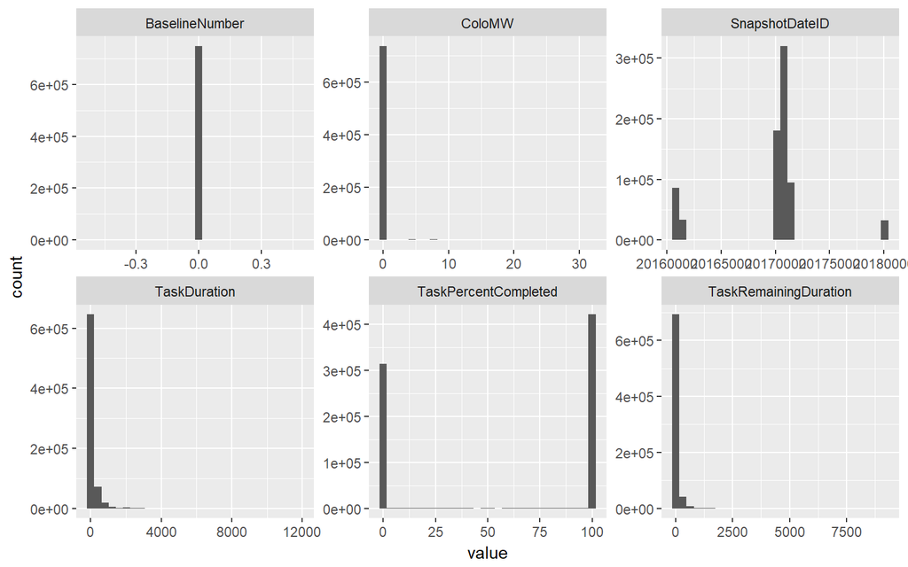

```r
library(purrr)
library(tidyr)

cntNumNames <- length((select_if(builddata,is.numeric)))
#Make plots max 6 at a time - change if needed
maxPlot = 6
loopCnt <- cntNumNames %/% maxPlot
remainder <- cntNumNames %% maxPlot

myLoop_DF <- data.frame(x = seq(1, cntNumNames-remainder, by = maxPlot), y = seq(6, cntNumNames, by = maxPlot))
myLoopMax <- max(myLoop_DF)

for(i in 1:nrow(myLoop_DF)){
  myplot <- select_if(data,is.numeric)[myLoop_DF[i,1]:myLoop_DF[i,2]]%>% gather() %>% ggplot(aes(value)) +
      facet_wrap(~ key, scales = "free") + geom_histogram() #+  geom_density()
  print(myplot)
}
```

### Plot Numeric Values for Lease

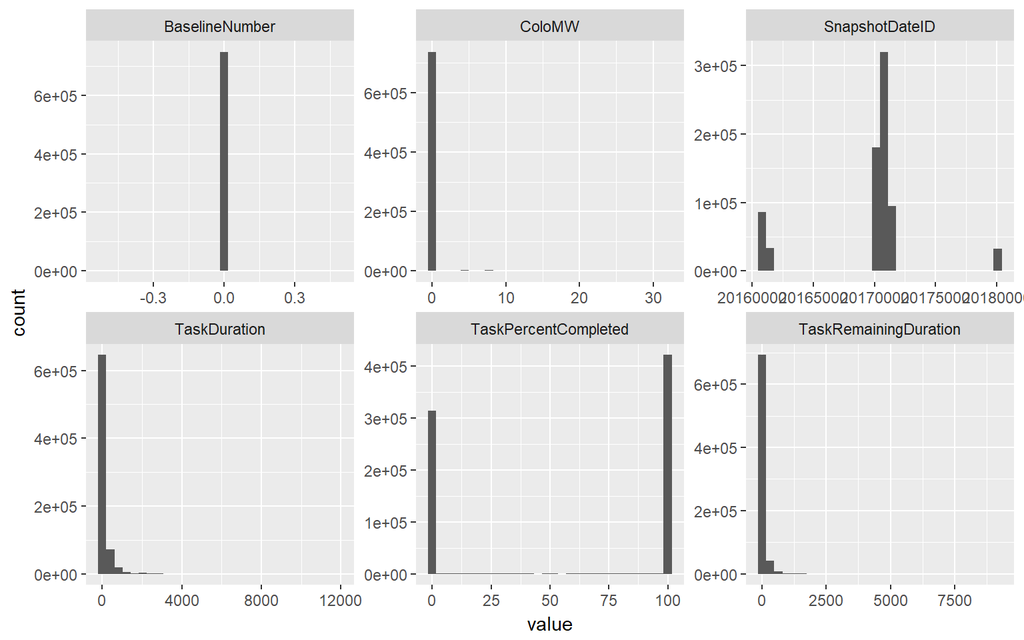

```r
library(purrr)
library(tidyr)

cntNumNames <- length((select_if(leasedata,is.numeric)))
#Make plots max 6 at a time - change if needed
maxPlot = 6
loopCnt <- cntNumNames %/% maxPlot
remainder <- cntNumNames %% maxPlot

myLoop_DF <- data.frame(x = seq(1, cntNumNames-remainder, by = maxPlot), y = seq(6, cntNumNames, by = maxPlot))
myLoopMax <- max(myLoop_DF)

for(i in 1:nrow(myLoop_DF)){
  myplot <- select_if(data,is.numeric)[myLoop_DF[i,1]:myLoop_DF[i,2]]%>% gather() %>% ggplot(aes(value)) +
      facet_wrap(~ key, scales = "free") + geom_histogram() #+  geom_density()
  print(myplot)
}
```

### Variability

Machine learning algorithms require patterns in data in order to develop a predictive algorithm. If the values are all the same in a column, there is no pattern. Below column variability is evaluated:

```r
#Col 1 -s StoreId, 20 is Status
myVariance <- as.data.frame(apply(builddata, 2, var))

myVariance <- tibble::rownames_to_column(myVariance)
names(myVariance)[2] <- "Variance"
myVariance <-  myVariance %>% mutate(Variance2 = ifelse(Variance == 0, "No", "Yes"))
table(myVariance$Variance2)
```

```
##
##  No Yes
##   1   8
```

Because 1 variable has no variance - all the values are the same - it can be removed from the working dataset. If there are no differences in a column, it is of no use in the development of an algorithm. The variable to be removed is:

```r
VarNames <- myVariance %>% filter(Variance > 0) %>% select(rowname)
zeroVarNames <- myVariance %>% filter(Variance == 0) %>% select(rowname)
#builddata <- builddata %>% select(StoreId, Status, unlist(VarNames))
zeroVarNames
```

| rowname |
| --- |
| BaselineNumber |

### Outlier Detection

In the working dataset, there is one variable, `TaskDuration` evaluated to identify potential outliers. Outliers are data points that are unusually distant from other data points. Outliers can signify a number of things, including measurement error, a statistical anomaly, or variability in the data. In this case outliers may represent particularly difficult tasks within projects.

There are many way to visualize outliers. Boxplots are the most commonly used visualization.

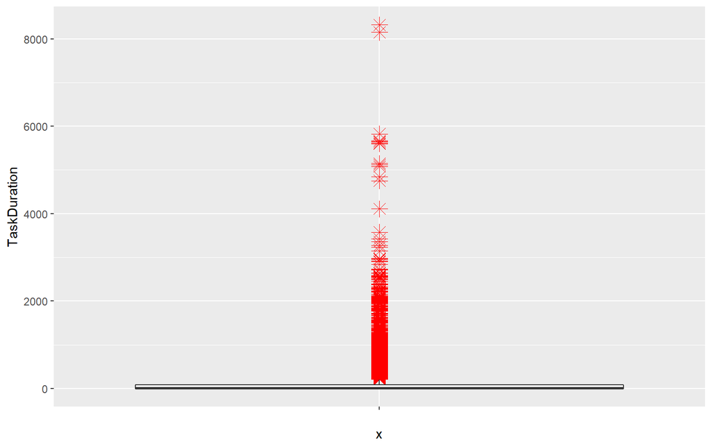

```r
out2 <- ggplot(builddata, aes(x = "", y = TaskDuration)) + geom_boxplot(outlier.color="red", outlier.shape=8, outlier.size=4)
print(out2)
```

The boxplot reveals that there are potential outliers.

Here is a list of the highest 50 `TaskDuration` records:

```r
tmpDuration <- arrange(data, desc(TaskDuration)) %>% select(ProjectID, ProgramType, TaskName, TaskDuration) %>% unique() %>% head(50)
#tmpDuration <- as.data.frame(head((tmpDuration$TaskDuration), 25))
#names(tmpDuration) <- "Task Duration"
tmpDuration
```

| ProjectID | ProgramType | TaskName | TaskDuration |
| --- | --- | --- | --- |
| 744ECAD3-AB79-E511-827F-E82AEA49C4F0 | Lease | (BY5) - Delay per Strategy (Lack of Demand) | 11840 |
| 83398269-47B8-E711-80D0-00155D50AE0D | Build | (MWH06) - Construction, Commissioning and Fitout for Fifth Tranche | 9184 |
| 116638EC-E2B5-E711-80D3-00155D50AC16 | Build | (MWH05) - Construction, Commissioning and Fitout for Fifth Tranche | 8672 |
| 6EB50D05-D629-E611-BD74-4851B7554DD9 | Build | (MWH04) - Construction, Commissioning and Fitout for Fifth Tranche | 8320 |
| 116638EC-E2B5-E711-80D3-00155D50AC16 | Build | (MWH05) - Construction, Commissioning and Fitout for Third Tranche | 8152 |
| 116638EC-E2B5-E711-80D3-00155D50AC16 | Build | (MWH05) - Construction, Commissioning and Fitout for Fourth Tranche | 8152 |
| 83398269-47B8-E711-80D0-00155D50AE0D | Build | (MWH06) - Construction, Commissioning and Fitout for Third Tranche | 8152 |
| 83398269-47B8-E711-80D0-00155D50AE0D | Build | (MWH06) - Construction, Commissioning and Fitout for Fourth Tranche | 8152 |
| 6EB50D05-D629-E611-BD74-4851B7554DD9 | Build | (MWH04) - Construction, Commissioning and Fitout for Fourth Tranche | 8152 |
| C03CE5C5-49F5-E411-8269-5CC5D488CC22 | Build | (DSM08) - Milestones | 7592 |

[output cut: 40 more lines]

> Microsft may be able to identify is any of these projects are uniquely outliers and should be removed from consideration.

### Duplicates

A duplicate value would mean the same task and task attributes were recorded within a single snapshot. There should be no reason for this to occur. As expected no duplicates are found because each record has a unique `TaskID` and `SnapshotDateID` value.

```r
# Duplicate Build Records
cat("The number of duplicated build records is", nrow(builddata) - nrow(unique(builddata)))
```

```
## The number of duplicated build records is 0
```

```r
# Duplicate Lease Records
cat("The number of duplicated lease records is", nrow(leasedata) - nrow(unique(leasedata)))
```

```
## The number of duplicated lease records is 0
```

Had a duplicate been identified, it might indicate a data entry error or perhaps data corruption. This is why the check is a necessary one.

# Data Analysis

The analysis portion of the exploratory analysis focuses on understanding the data within the business context and how it could be used in a data science model. The analyses includes:

- Project Types and Status
- Task Analysis
- Milestone Analysis
- Project Duration

## Project Types & Status

There are only a small number of Build Projects. The number of projects/type are examined by project status (active or complete).

```r
data %>%  group_by(ProgramType) %>% summarise(ProjectCount = n_distinct(ProjectID),
                                      Active = n_distinct(ProjectID[ProjectStatus == "Active"]),
                                      Complete = n_distinct(ProjectID[ProjectStatus == "Complete"]))
```

| ProgramType | ProjectCount | Active | Complete |
| --- | --- | --- | --- |
| Build | 22 | 17 | 5 |
| Lease | 30 | 20 | 10 |

```r
builddata %>% group_by(DCType) %>% summarise(ProjectCount = n_distinct(ProjectID),
                                       Active = n_distinct(ProjectID[ProjectStatus == "Active"]),
                                       Complete = n_distinct(ProjectID[ProjectStatus == "Complete"]))
```

| DCType | ProjectCount | Active | Complete |
| --- | --- | --- | --- |
| DC 2015 | 3 | 0 | 3 |
| DC2015.5 | 5 | 5 | 0 |
| Gen 4.5 | 2 | 0 | 2 |
| Gen 4.6 | 1 | 1 | 0 |
| ITPAC | 3 | 3 | 0 |
| Scalable Form Factor | 6 | 6 | 0 |

Of the projects for which we have data, **only 5 Build and 10 Lease have completed**. This leaves 17 active Build and 20 active Lease projects.

A further breakdown of these projects by `DCType` illustrates some interesting results. **The only completed projects are DC 2015 and Gen 4.5**. The rest of the project types, which all appear to be newer, do not have any completed projects.

The lack of fully completed projects poses a problem for analysis. In order to develop an algorithm, a critical mass of data is needed with which a model can be trained to identify patterns. Ideally there would be a significant number of completed projects for each of the different program types so that observations regarding the full lifecycle of a project could be made. Based on those observations predictions could be made about what may happen to similar projects in the future.

> Completed projects are required for machine learnig algorithms to learn from.

If common factors between different projects are found, it may be possible to identify patterns that extend to all Build projects regardless of type.

> The lack of historical data suggests Active projects may need to be considered for analysis. It may be possible to use project checkpoints and milestones from active projects to aid in the devlopment of a predictive tool.

## Project Task Analysis

If there are common project tasks across project types, useful data for analysis may be identified. To evaluate this opportunity, the following exercises are performed:

- Project Task Counts
- Project Task Plots for Build by Type and Lease
- Project Tasks by Tranch
- Common Task Identification

### Project Task Counts

The number of unique tasks in a project may indicate the complexity of a project. A count of the number of tasks per each snapshot of data is calculated. The task counts are plotted by weekly snapshot to show project activity over time. The shape of these graphs provides insights into activity levels as a project progresses.

Below, note the significant variation in the shape of the plots. The number of tasks by project is also inconsistent.

#### ITPAC

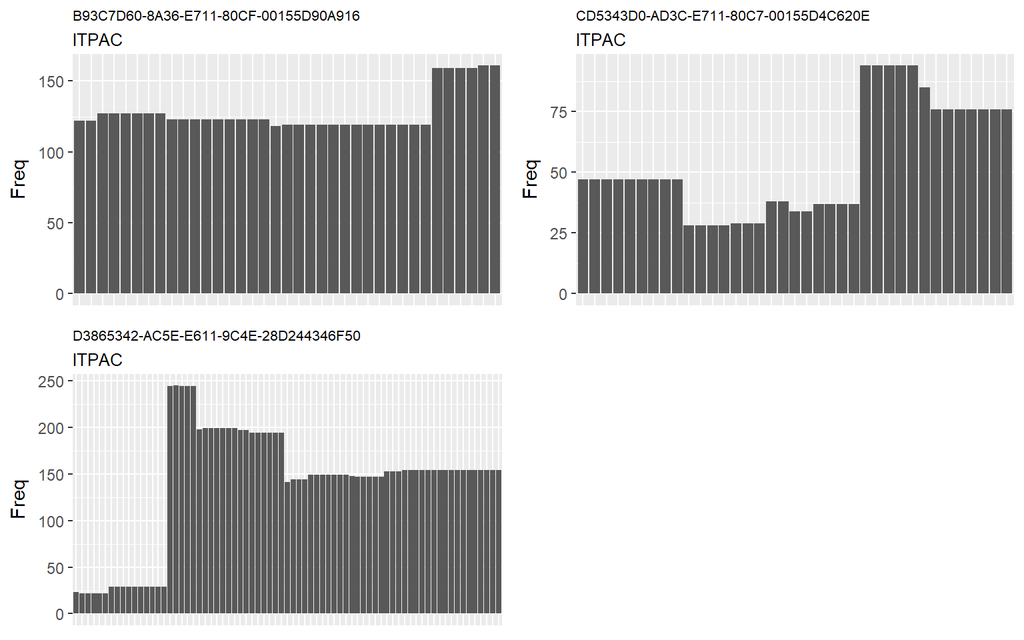

```r
library(gridExtra)

##################
#     ITPAC      #
##################

#Graph all ITPAC projects task counts
cntNumProjects <- nrow((distinct(ITPACTaskCounts, ProjectID)))
ProjectList <- data.frame(distinct(ITPACTaskCounts, ProjectID))

for(i in 1:cntNumProjects){
     df1 <- ITPACTaskCounts %>% filter(ProjectID == ProjectList[i,1])

     assign(paste0("plot", i),ggplot(df1, aes(x=SnapshotDateID, y=Freq)) +
          geom_bar(stat="identity") + ggtitle(ProjectList[i,1], subtitle = "ITPAC") + theme(axis.title.x=element_blank(),
          axis.text.x=element_blank(),  axis.ticks.x=element_blank()) + theme(plot.title = element_text(size = 8)))
}

grid.arrange(plot1, plot2, plot3, ncol=2)
```

Note the difference in the number of tasks and the variability in number of tasks between snapshots.

#### Scalable Form Factor

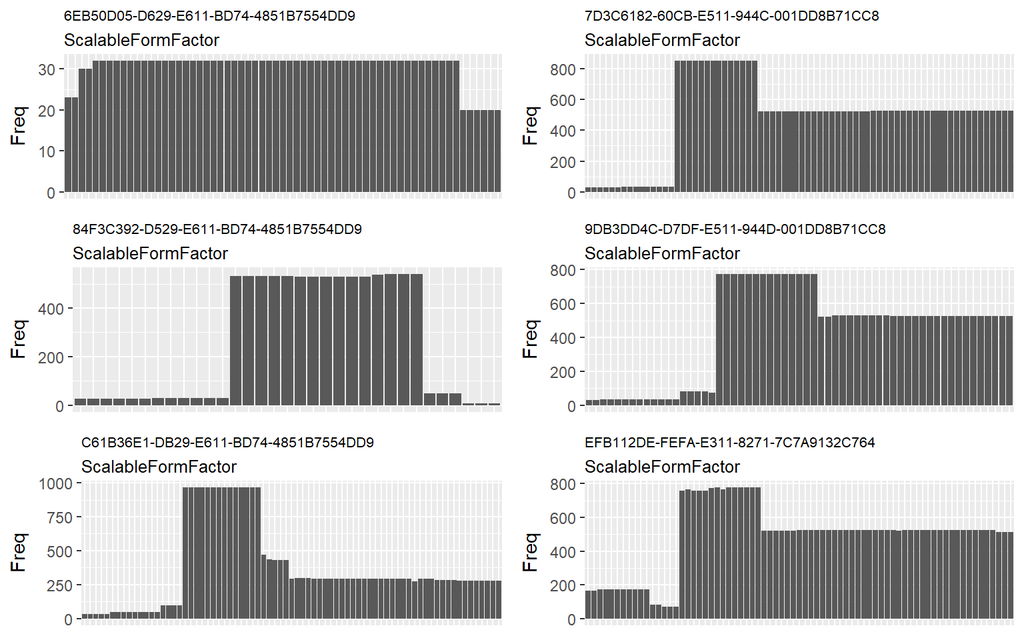

```r
########################
#  ScalableFormFactor  #
########################

#Graph all ScalableFormFactor projects task counts
cntNumProjects <- nrow((distinct(ScalableFormFactorTaskCounts, ProjectID)))
ProjectList <- data.frame(distinct(ScalableFormFactorTaskCounts, ProjectID))

for(i in 1:cntNumProjects){
     df1 <- ScalableFormFactorTaskCounts %>% filter(ProjectID == ProjectList[i,1])

     assign(paste0("plot", i),ggplot(df1, aes(x=SnapshotDateID, y=Freq)) +
          geom_bar(stat="identity") + ggtitle(ProjectList[i,1], subtitle = "ScalableFormFactor") + theme(axis.title.x=element_blank(),
          axis.text.x=element_blank(),  axis.ticks.x=element_blank()) + theme(plot.title = element_text(size = 8)))
}

grid.arrange(plot1, plot2, plot3, plot4, plot5, plot6, ncol=2)
```

```r
#grid.arrange(plot7, plot8, ncol=2)
```

#### Gen 4.5

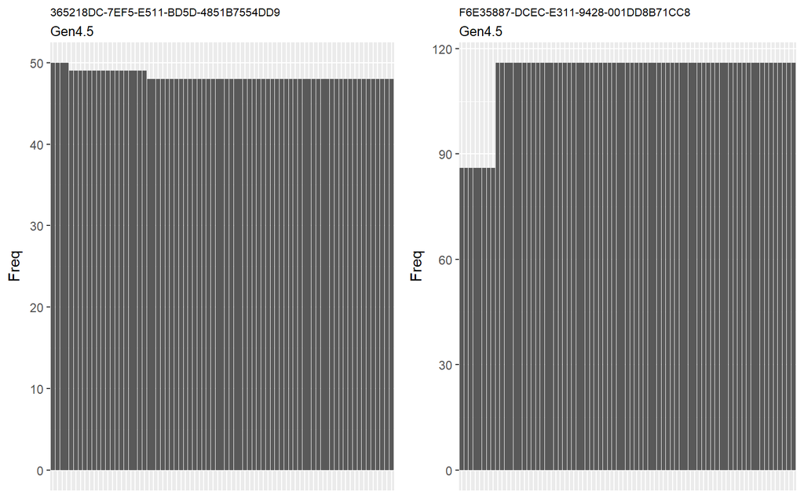

```r
###################
#     Gen4.5      #
###################

#Graph all Gen4.5 projects task counts
cntNumProjects <- nrow((distinct(Gen4.5TaskCounts, ProjectID)))
ProjectList <- data.frame(distinct(Gen4.5TaskCounts, ProjectID))

for(i in 1:cntNumProjects){
     df1 <- Gen4.5TaskCounts %>% filter(ProjectID == ProjectList[i,1])

     assign(paste0("plot", i),ggplot(df1, aes(x=SnapshotDateID, y=Freq)) +
          geom_bar(stat="identity") + ggtitle(ProjectList[i,1], subtitle = "Gen4.5") + theme(axis.title.x=element_blank(),
          axis.text.x=element_blank(),  axis.ticks.x=element_blank()) + theme(plot.title = element_text(size = 8)))
}

grid.arrange(plot1, plot2, ncol=2)
```

#### Gen 4.6

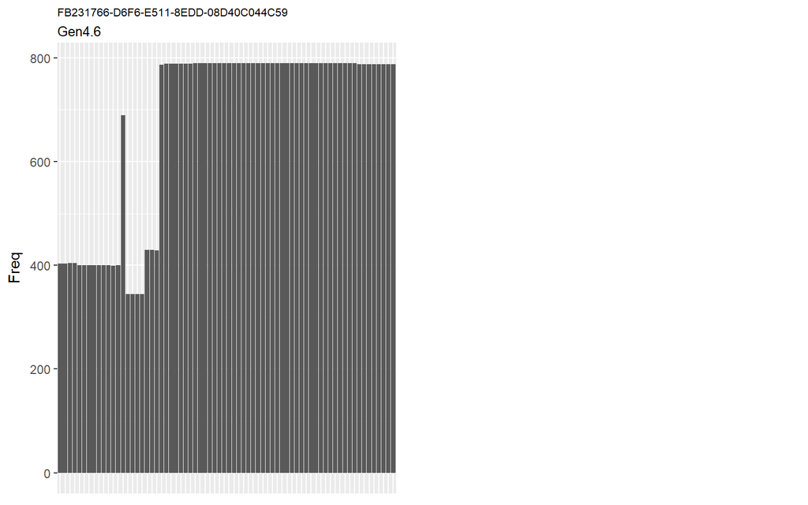

```r
###################
#     Gen4.6      #
###################

#Graph all Gen4.6 projects task counts
cntNumProjects <- nrow((distinct(Gen4.6TaskCounts, ProjectID)))
ProjectList <- data.frame(distinct(Gen4.6TaskCounts, ProjectID))

for(i in 1:cntNumProjects){
     df1 <- Gen4.6TaskCounts %>% filter(ProjectID == ProjectList[i,1])

     assign(paste0("plot", i),ggplot(df1, aes(x=SnapshotDateID, y=Freq)) +
          geom_bar(stat="identity") + ggtitle(ProjectList[i,1], subtitle = "Gen4.6") + theme(axis.title.x=element_blank(),
          axis.text.x=element_blank(),  axis.ticks.x=element_blank()) + theme(plot.title = element_text(size = 8)))
}

grid.arrange(plot1, ncol=2)
```

#### DC 2015

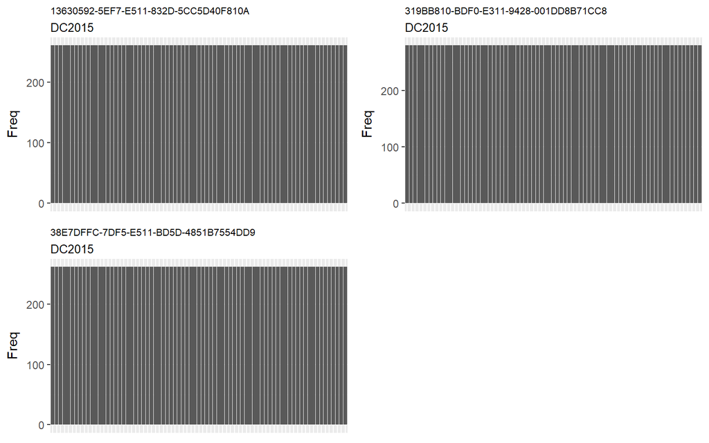

```r
###################
#     DC2015      #
###################

#Graph all DC2015 projects task counts
cntNumProjects <- nrow((distinct(DC2015TaskCounts, ProjectID)))
ProjectList <- data.frame(distinct(DC2015TaskCounts, ProjectID))

for(i in 1:cntNumProjects){
     df1 <- DC2015TaskCounts %>% filter(ProjectID == ProjectList[i,1])

     assign(paste0("plot", i),ggplot(df1, aes(x=SnapshotDateID, y=Freq)) +
          geom_bar(stat="identity") + ggtitle(ProjectList[i,1], subtitle = "DC2015") + theme(axis.title.x=element_blank(),
          axis.text.x=element_blank(),  axis.ticks.x=element_blank()) + theme(plot.title = element_text(size = 8)))
}

grid.arrange(plot1, plot2, plot3, ncol=2)
```

#### DC 2015.5

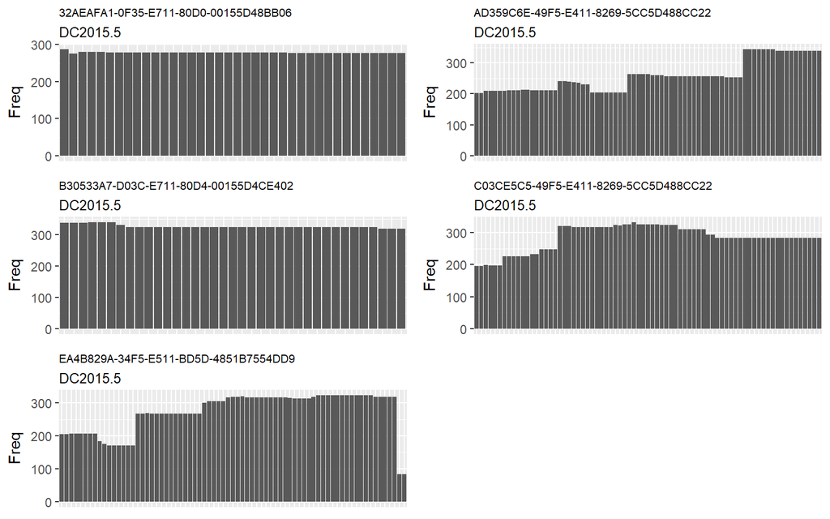

```r
#####################
#     DC2015.5      #
#####################

#Graph all DC2015.5 projects task counts
cntNumProjects <- nrow((distinct(DC2015.5TaskCounts, ProjectID)))
ProjectList <- data.frame(distinct(DC2015.5TaskCounts, ProjectID))

for(i in 1:cntNumProjects){
     df1 <- DC2015.5TaskCounts %>% filter(ProjectID == ProjectList[i,1])

     assign(paste0("plot", i),ggplot(df1, aes(x=SnapshotDateID, y=Freq)) +
          geom_bar(stat="identity") + ggtitle(ProjectList[i,1], subtitle = "DC2015.5") + theme(axis.title.x=element_blank(),
          axis.text.x=element_blank(),  axis.ticks.x=element_blank()) + theme(plot.title = element_text(size = 8)))
}

grid.arrange(plot1, plot2, plot3, plot4, plot5, ncol=2)
```

There is little consistency illustrated above. While Gen 4.5 and DC 2015 show some consistency between projects, Scalable Form Factor and DC 2015.5, which contain the bulk of the current active projects, do not show data patterns. (Gen 4.6 has only one project and therefore there is nothing to compare.)

### Plot Lease Task Counts

The same task counts per snapshot were plotted for the Lease projects.

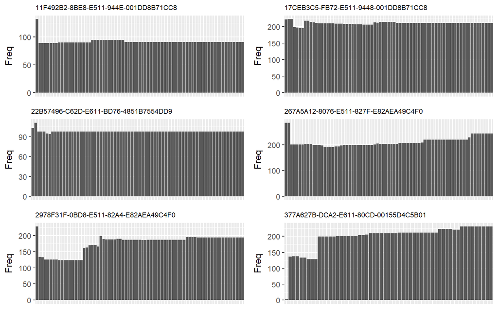

```r
library(gridExtra)

#Graph all build projects task counts
cntNumProjects <- nrow((distinct(leaseTaskCounts, ProjectID)))
ProjectList <- data.frame(distinct(leaseTaskCounts, ProjectID))

for(i in 1:cntNumProjects){
     df1 <- leaseTaskCounts %>% filter(ProjectID == ProjectList[i,1])

     assign(paste0("plot", i),ggplot(df1, aes(x=SnapshotDateID, y=Freq)) +
          geom_bar(stat="identity") + ggtitle(ProjectList[i,1]) + theme(axis.title.x=element_blank(),
          axis.text.x=element_blank(),  axis.ticks.x=element_blank()) + theme(plot.title = element_text(size = 8)))
}

grid.arrange(plot1, plot2, plot3, plot4, plot5, plot6, ncol=2)
```

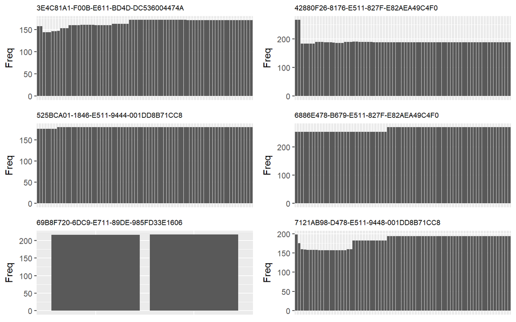

```r
grid.arrange(plot7, plot8, plot9, plot10, plot11, plot12, ncol=2)
```

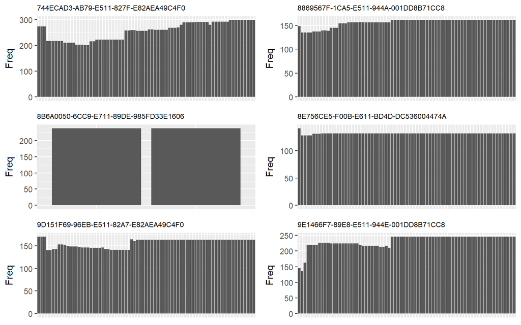

```r
grid.arrange(plot13, plot14, plot15, plot16, plot17, plot18, ncol=2)
```

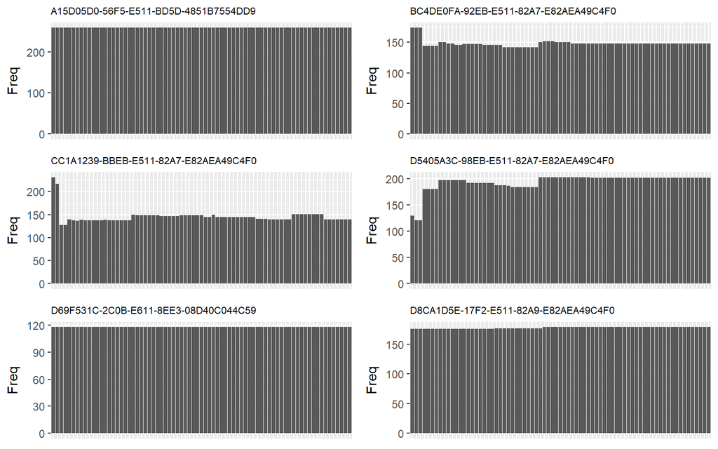

```r
grid.arrange(plot19, plot20, plot21, plot22, plot23, plot24, ncol=2)
```

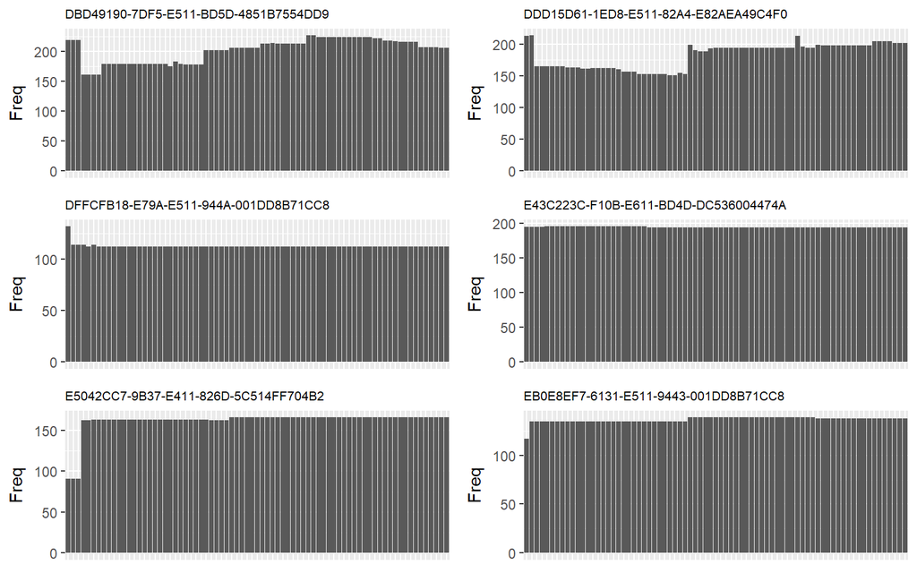

```r
grid.arrange(plot25, plot26, plot27, plot28, plot29, plot30, ncol=2)
```

The Lease graphs show more consistency than the Build projects.

> Perhaps this should become a focus for futher development.

### Tasks per Tranche

The variations in the total tasks between projects of the same type may be explain by the number of tranches in a project. Two tranches may logically have the twice the number of tasks involved as a single tranche. The number of tranches and tasks per tranche are calculated by snapshot.

#### ITPAC

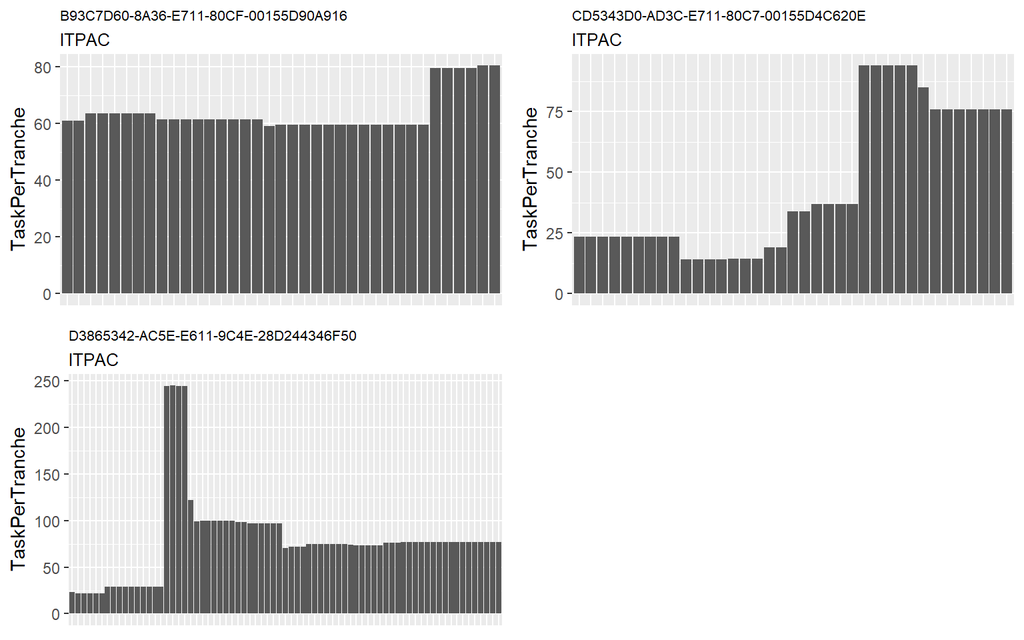

```r
pertranche <- function(x) {

  df <- data %>%
        group_by(ProjectID, SnapshotDateID) %>%
        summarise(NumberTranches = ifelse( !all(is.na(Tranche)), n_distinct(Tranche, na.rm=TRUE), 1))

  df$SnapshotDateID <- factor(df$SnapshotDateID)
  inner_join(x, df)
}

pertranchegroup <- function(x) {
  df<-
pertranche(x) %>%
    group_by(ProjectID, SnapshotDateID, Freq, NumberTranches) %>%
    summarise(TaskPerTranche = Freq / NumberTranches)
df <- ungroup(df)
}

#ITPACT task counts
ITPACTrancheTask <- pertranchegroup(ITPACTaskCounts)

#ScalableFormFactor task counts
ScalableFormFactorTrancheTask <- pertranchegroup(ScalableFormFactorTaskCounts)

#Gen4.5 task counts
Gen4.5TrancheTask <- pertranchegroup(Gen4.5TaskCounts)

#Gen4.6 task counts
Gen4.6TrancheTask <- pertranchegroup(Gen4.6TaskCounts)

#DC2015 task counts
DC2015TrancheTask <- pertranchegroup(DC2015TaskCounts)

#DC2015.5 task counts
DC2015.5TrancheTask <- pertranchegroup(DC2015.5TaskCounts)

#Lease task counts
leaseTrancheTask <- pertranchegroup(leaseTaskCounts)

##################
#     ITPAC      #
##################

#Graph all ITPAC projects task counts
cntNumProjects <- nrow((distinct(ITPACTrancheTask, ProjectID)))
ProjectList <- data.frame(distinct(ITPACTrancheTask, ProjectID))

for(i in 1:cntNumProjects){
     df1 <- ITPACTrancheTask %>% filter(ProjectID == ProjectList[i,1])

     assign(paste0("plot", i),ggplot(df1, aes(x=SnapshotDateID, y=TaskPerTranche)) +
          geom_bar(stat="identity") + ggtitle(ProjectList[i,1], subtitle = "ITPAC") + theme(axis.title.x=element_blank(),
          axis.text.x=element_blank(),  axis.ticks.x=element_blank()) + theme(plot.title = element_text(size = 8)))
}

grid.arrange(plot1, plot2, plot3, ncol=2)
```

#### Scalable Form Factor

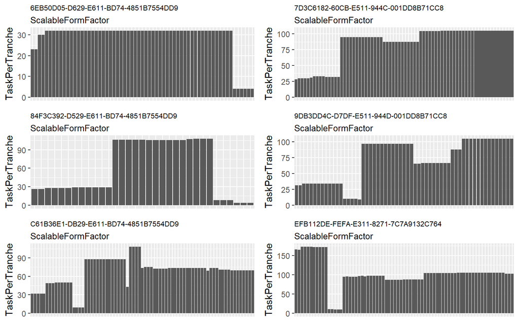

```r
########################
#  ScalableFormFactor  #
########################

#Graph all ScalableFormFactor projects task counts
cntNumProjects <- nrow((distinct(ScalableFormFactorTrancheTask, ProjectID)))
ProjectList <- data.frame(distinct(ScalableFormFactorTrancheTask, ProjectID))

for(i in 1:cntNumProjects){
     df1 <- ScalableFormFactorTrancheTask %>% filter(ProjectID == ProjectList[i,1])

     assign(paste0("plot", i),ggplot(df1, aes(x=SnapshotDateID, y=TaskPerTranche)) +
          geom_bar(stat="identity") + ggtitle(ProjectList[i,1], subtitle = "ScalableFormFactor") + theme(axis.title.x=element_blank(),
          axis.text.x=element_blank(),  axis.ticks.x=element_blank()) + theme(plot.title = element_text(size = 8)))
}

grid.arrange(plot1, plot2, plot3, plot4, plot5, plot6, ncol=2)
```

[figure not shown]

```r
grid.arrange(plot7, plot8, ncol=2)
```

#### Gen 4.5

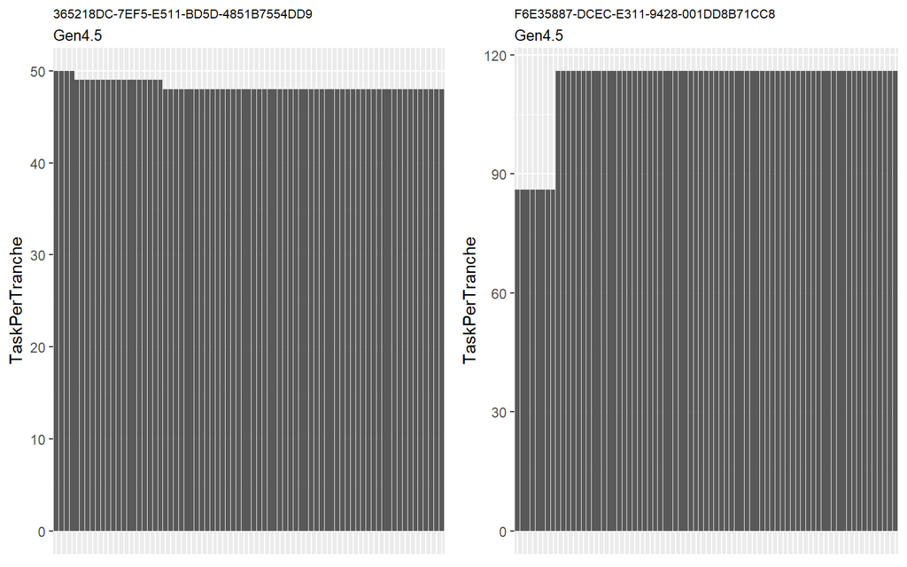

```r
###################
#     Gen4.5      #
###################

#Graph all Gen4.5 projects task counts
cntNumProjects <- nrow((distinct(Gen4.5TrancheTask, ProjectID)))
ProjectList <- data.frame(distinct(Gen4.5TrancheTask, ProjectID))

for(i in 1:cntNumProjects){
     df1 <- Gen4.5TrancheTask %>% filter(ProjectID == ProjectList[i,1])

     assign(paste0("plot", i),ggplot(df1, aes(x=SnapshotDateID, y=TaskPerTranche)) +
          geom_bar(stat="identity") + ggtitle(ProjectList[i,1], subtitle = "Gen4.5") + theme(axis.title.x=element_blank(),
          axis.text.x=element_blank(),  axis.ticks.x=element_blank()) + theme(plot.title = element_text(size = 8)))
}

grid.arrange(plot1, plot2, ncol=2)
```

#### Gen 4.6

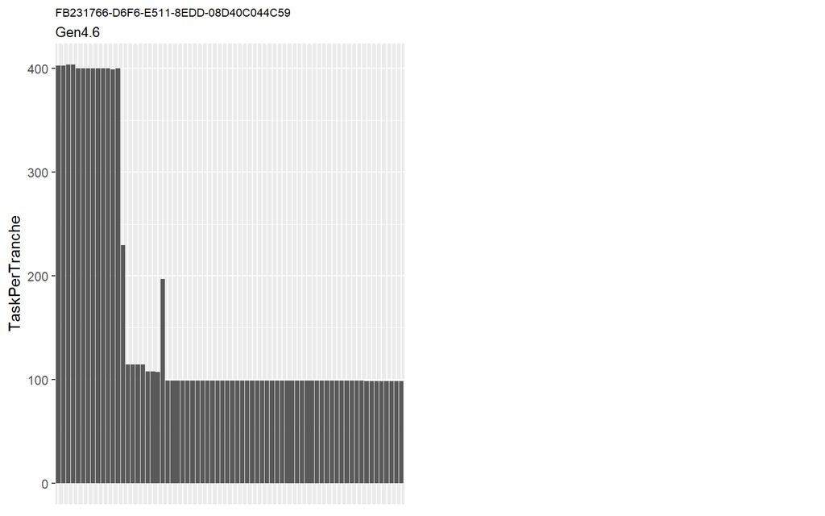

```r
###################
#     Gen4.6      #
###################

#Graph all Gen4.6 projects task counts
cntNumProjects <- nrow((distinct(Gen4.6TrancheTask, ProjectID)))
ProjectList <- data.frame(distinct(Gen4.6TrancheTask, ProjectID))

for(i in 1:cntNumProjects){
     df1 <- Gen4.6TrancheTask %>% filter(ProjectID == ProjectList[i,1])

     assign(paste0("plot", i),ggplot(df1, aes(x=SnapshotDateID, y=TaskPerTranche)) +
          geom_bar(stat="identity") + ggtitle(ProjectList[i,1], subtitle = "Gen4.6") + theme(axis.title.x=element_blank(),
          axis.text.x=element_blank(),  axis.ticks.x=element_blank()) + theme(plot.title = element_text(size = 8)))
}

grid.arrange(plot1, ncol=2)
```

#### DC 2015

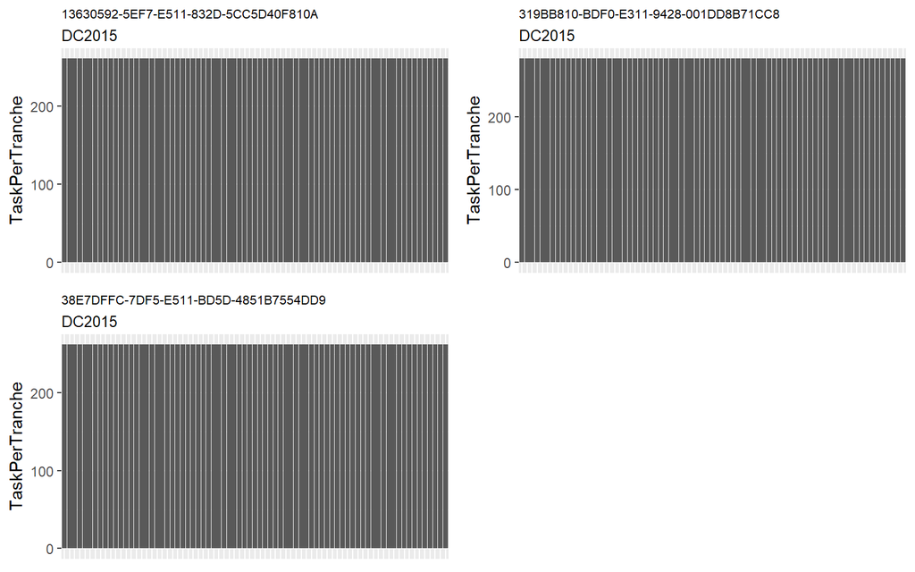

```r
###################
#     DC2015      #
###################

#Graph all DC2015 projects task counts
cntNumProjects <- nrow((distinct(DC2015TrancheTask, ProjectID)))
ProjectList <- data.frame(distinct(DC2015TrancheTask, ProjectID))

for(i in 1:cntNumProjects){
     df1 <- DC2015TrancheTask %>% filter(ProjectID == ProjectList[i,1])

     assign(paste0("plot", i),ggplot(df1, aes(x=SnapshotDateID, y=TaskPerTranche)) +
          geom_bar(stat="identity") + ggtitle(ProjectList[i,1], subtitle = "DC2015") + theme(axis.title.x=element_blank(),
          axis.text.x=element_blank(),  axis.ticks.x=element_blank()) + theme(plot.title = element_text(size = 8)))
}

grid.arrange(plot1, plot2, plot3, ncol=2)
```

Note the consistency in the DC 2015 Build project type above.

#### DC 2015.5

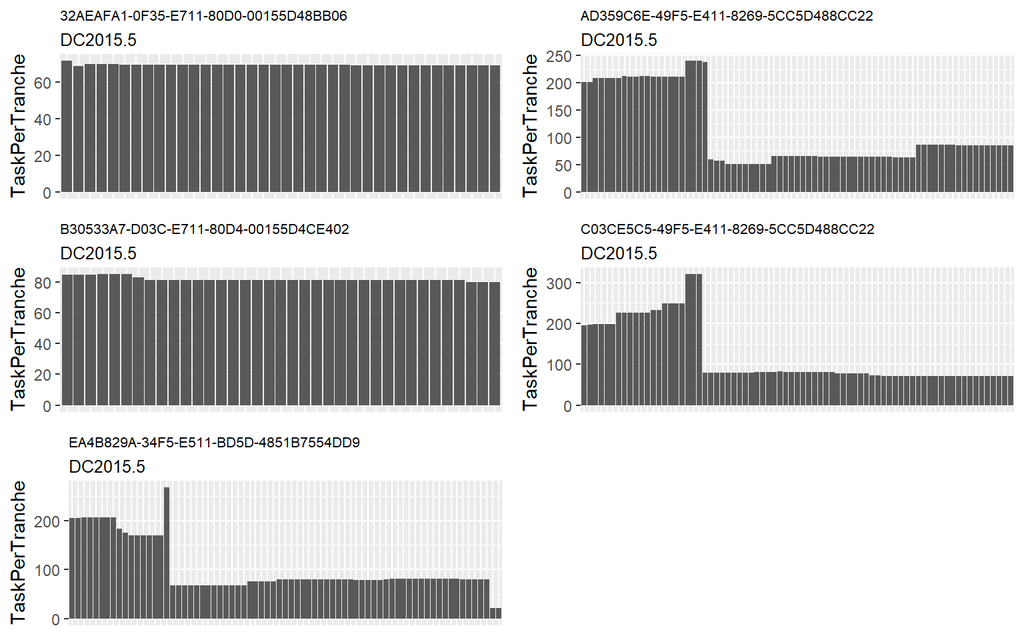

```r
#####################
#     DC2015.5      #
#####################

#Graph all DC2015.5 projects task counts
cntNumProjects <- nrow((distinct(DC2015.5TrancheTask, ProjectID)))
ProjectList <- data.frame(distinct(DC2015.5TrancheTask, ProjectID))

for(i in 1:cntNumProjects){
     df1 <- DC2015.5TrancheTask %>% filter(ProjectID == ProjectList[i,1])

     assign(paste0("plot", i),ggplot(df1, aes(x=SnapshotDateID, y=TaskPerTranche)) +
          geom_bar(stat="identity") + ggtitle(ProjectList[i,1], subtitle = "DC2015.5") + theme(axis.title.x=element_blank(),
          axis.text.x=element_blank(),  axis.ticks.x=element_blank()) + theme(plot.title = element_text(size = 8)))
}

grid.arrange(plot1, plot2, plot3, plot4, plot5, ncol=2)
```

> The graphs of the tasks per tranche also illustrate a high degree of variability.

## Common Project Tasks

Assess how many tasks common across all projects and within the project type groups. Discover which task names appeared in all of the Build projects and within project types.

### All Build Data

```r
common <- function(x) {
  common <- data.frame()
commontemp <- data.frame()
cntNumProjects <- nrow((distinct(x, ProjectID)))
ProjectList <- data.frame(distinct(x, ProjectID))

for(i in 2:cntNumProjects){
     df1 <- x %>% filter(ProjectID == ProjectList[i-1,1]) %>% select(TaskPlain)
     df2 <- x %>% filter(ProjectID == ProjectList[i,1]) %>% select(TaskPlain)

     commontemp <- intersect(df1,df2)

     common <- if (length(common)==0) {
       commontemp
     } else {
       intersect(common,commontemp)
     }}

  common
}

common(builddata)
```

| TaskPlain |
| --- |

### ITPAC

```r
ITPACcommon <- common(ITPAC)
ITPACcommon
```

| TaskPlain |
| --- |
| Construction Start |
| Design 60% Complete |
| Design IFC |
| FIDS Equipment Procurement Start |
| Construction Complete |
| Fabric Complete for First Tranche |
| Security Lockdown for First Tranche |
| Turnover to Ops for First Tranche |
| Schedule Margin to First Footprint Colo Ready |

[output cut: 81 more lines]

### Scalable Form Factor

```r
ScalableFormFactorcommon <- common(ScalableFormFactor)
ScalableFormFactorcommon
```

| TaskPlain |
| --- |
| Complete Deployment to RTEG for First Tranche |
| Complete Deployment to RTEG for Second Tranche |
| Complete Deployment to RTEG for Third Tranche |
| Complete Deployment to RTEG for Fourth Tranche |
| Complete Deployment to RTEG for Fifth Tranche |

### Gen 4.5

```r
Gen4.5common <- common(Gen4.5)
Gen4.5common
```

| TaskPlain |
| --- |
| Turnover to Operations |
| DC Build Close-out Complete |
| ROJ/1st for Generator Complete |
| ROJ/1st for MVS Complete |
| ROJ/1st for Subs/LV Gear/XFMR Complete |
| ROJ/1st for UPS/Batteries Complete |
| ROJ/1st for CAHU Complete |
| Ops Training |
| Deployment (Azure) |

### Gen 4.6

```r
Gen4.6common <- as.data.frame(unique(Gen4.6$TaskPlain))
names(Gen4.6common) <- "TaskPlain"
Gen4.6common
```

| TaskPlain |
| --- |
| Construction Start (Break Ground) |
| Colo Definition Established (Colo Ready Review) |
| Design IFC |
| Integrated Baseline Review Complete |
| Decision Gate Meeting Held (Commit/Baseline Date alignment) |
| Core Network Complete |
| DCPS Security Lockdown |
| DC Build Close-out Complete |
| RTEG |
| First Footprint RTEG |

[output cut: 836 more lines]

### DC 2015

```r
DC2015common <- common(DC2015)
DC2015common
```

| TaskPlain |
| --- |
| AZA Construction |
| AZA Early Access (GC Readiness) |
| AZA MGFX/EPMS/BAS Rack Install, Cabling and Verification Complete |
| AZA Cell 1 Beneficial Use |
| AZB Construction |
| AZB Early Access (GC Readiness) |
| AZB MGFX/EPMS/BAS Rack Install, Cabling and Verification Complete |
| AZB Cell 1 Beneficial Use |
| AZC Construction |
| AZC Early Access (GC Readiness) |

[output cut: 62 more lines]

### DC 2015.5

```r
DC2015.5common <- common(DC2015.5)
DC2015.5common
```

| TaskPlain |
| --- |
| Construction Start |
| Schedule Margin to First Footprint Colo Ready |
| EPMS ROJ |
| UPS ROJ |
| Network Fabric Program Kickoff, Network Engineer (NE) Assigned |
| Create Network Fabric Early Access (MGFX) Design, BOM and Rack Elevations |
| Initiate Network Fabric Early Access Procurement |
| Network Fabric Early Access Procurement Lead Time |
| Network Fabric Early Access On Dock |
| Develop Network Fabric Early Access AP Cluster |

[output cut: 68 more lines]

> There are not any tasks that are common among all projects.

### Common Tasks Within Lease Project Types

Lease project tasks were analyzed for task commonality.

```r
#Loop to go through all lease projects and find common
leasecommon <- data.frame()
commontaskstemp <- data.frame()
cntNumProjects <- nrow((distinct(leasedata, ProjectID)))
ProjectList <- data.frame(distinct(leasedata, ProjectID))

for(i in 2:cntNumProjects){
     taskdf1 <- leasedata %>% filter(ProjectID == ProjectList[i-1,1]) %>% select(TaskPlain)
     taskdf2 <- leasedata %>% filter(ProjectID == ProjectList[i,1]) %>% select(TaskPlain)

     commontaskstemp <- intersect(taskdf1,taskdf2)

     leasecommon <- if (length(leasecommon)==0) {
       commontaskstemp
     } else {
       intersect(leasecommon,commontaskstemp)
     }}

leasecommon
```

| TaskPlain |
| --- |

> Similar to Build projects, there were no common task names for all of the Lease projects.

### Common Task Summary

A summary table of the common tasks compared to the total number of unique task names per project was compiled.

```r
DCType <- c('ITPAC','Scalable Form Factor','Gen 4.5', 'DC 2015','DC2015.5')

typecommontasks <- c(as.numeric(length(ITPACcommon$TaskPlain)), as.numeric(length(ScalableFormFactorcommon$TaskPlain)),  as.numeric(length(Gen4.5common$TaskPlain)), as.numeric(length(DC2015common$TaskPlain)), as.numeric(length(DC2015.5common$TaskPlain)))

projectcommontasks <- data.frame(DCType, typecommontasks)

projecttaskcount <-
  builddata %>%
  group_by(DCType) %>%
  summarise(TotalTasks = n_distinct(TaskPlain))

  inner_join(projecttaskcount, projectcommontasks)
```

| DCType | TotalTasks | typecommontasks |
| --- | --- | --- |
| DC 2015 | 539 | 72 |
| DC2015.5 | 1112 | 78 |
| Gen 4.5 | 161 | 9 |
| ITPAC | 595 | 91 |
| Scalable Form Factor | 1663 | 5 |

> Scalable Form Factor projects have the most unique task names and also the least number of tasks in common.

## Milestone Analysis

Project milestones are evaluated to find commonality between projects.

Microsoft provided a list of `L2Milestones` common to all projects.

**Build Milestones**

1. Signal Received 2.Charter Approved
2. Design Kick off
3. Issue for Construction (Design Complete)
4. Construction Start
5. Beneficial Use
6. CX Level 3 Complete
7. IST Complete
8. Security Lockdown
9. Turnover to Ops
10. Colo Ready
11. RTEG

**Lease Milestones**

1. apex Council Approved
2. Charter Approved
3. Signal Received
4. Site Selection Approved
5. Lease Contract Executed
6. High Confidence RFS
7. OPS Fitout Complete
8. Colo Ready
9. Security Lockdown
10. RTEG

Examine which milestones are common between all project types and within each project type group:

### All Build Projects

```r
common <- function(x) {
  common <- data.frame()
commontemp <- data.frame()
cntNumProjects <- nrow((distinct(x, ProjectID)))
ProjectList <- data.frame(distinct(x, ProjectID))

x <- filter(x, L2Milestone != "N/A")

for(i in 2:cntNumProjects){
     df1 <- x %>% filter(ProjectID == ProjectList[i-1,1]) %>% select(L2Milestone)
     df2 <- x %>% filter(ProjectID == ProjectList[i,1]) %>% select(L2Milestone)

     commontemp <- intersect(df1,df2)

     common <- if (length(common)==0) {
       commontemp
     } else {
       intersect(common,commontemp)
     }}

  common
}

common(builddata)
```

| L2Milestone |
| --- |
| Colo Ready |
| RTEG |

### ITPAC

```r
#ITPAC
ITPACmilestone <- common(ITPAC)
ITPACmilestone
```

| L2Milestone |
| --- |
| Colo Ready |
| RTEG |
| Cx Level 3 Complete |
| ITSE Access to CorpNet |
| RTW |
| CX Level 4 Complete |
| T2 Fabric Complete |
| Design 60%Â Complete |
| Issue for Construction Documents (IFC) |
| Construction Start |

[output cut: 13 more lines]

### Scalable Form Factor

```r
#ScalableFormFactor
ScalableFormFactormilestone <- common(ScalableFormFactor)
ScalableFormFactormilestone
```

| L2Milestone |
| --- |
| Colo Ready |
| RTEG |
| Issue for Construction Documents (IFC) |
| RTW |
| Cx Level 3 Complete |
| Substantial Completion |
| CX Level 4 Complete |
| T2 Fabric Complete |

### Gen 4.5

```r
#Gen4.5
Gen4.5milestone <- common(Gen4.5)
Gen4.5milestone
```

| L2Milestone |
| --- |
| Construction Start |
| Turnover to Ops |
| Colo Ready |
| RTEG |
| ROJ Delivery |
| Cx Level 3 Complete |
| CX Level 4 Complete |
| IST Complete |
| Security Lockdown |
| T2 Fabric Complete |

### Gen 4.6

```r
#Gen4.6
Gen4.6milestone <- as.data.frame(unique(Gen4.6$L2Milestone), col.names = "L2Milestone")
colnames(Gen4.6milestone) <- c("L2Milestone")
Gen4.6milestone
```

| L2Milestone |
| --- |
| N/A |
| RTEG |
| Colo Ready |
| Issue for Construction Documents (IFC) |
| Construction Start |
| T-90 Checkpoint |
| Construction Complete |
| T2 Fabric Complete |
| Security Lockdown |
| Turnover to Ops |

[output cut: 19 more lines]

### DC 2015

```r
#DC2015
DC2015milestone <- common(DC2015)
DC2015milestone
```

| L2Milestone |
| --- |
| Issue for Construction Documents (IFC) |
| Core Network Complete |
| Colo Ready |
| RTEG |

### DC 2015.5

```r
#DC2015.5
DC2015.5milestone <- common(DC2015.5)
DC2015.5milestone
```

| L2Milestone |
| --- |
| Colo Ready |
| RTEG |
| RTW |
| T-90 Checkpoint |
| Construction Complete |
| Security Lockdown |
| Turnover to Ops |
| Schedule Margin |
| Project Complete |
| Construction Start |

[output cut: 8 more lines]

### Lease

```r
#leasedata
leasedatamilestone <- common(leasedata)
leasedatamilestone
```

| L2Milestone |
| --- |
| CAPEX Council Approved |
| Lease Contract Executed |
| Colo Ready |
| RTEG |
| RTW |
| Site Selection Handover Complete |

> The analysis revealed there are only two common milestones among all Build projects, “Colo Ready” and “RTEG.”

As with tasks, the lack of common milestones makes cross project type analysis difficult. It is possible some of the milestones may have specific names per project but are equivalent to milestones on other projects.

> A translation of these milestones to common terms could help improve the commonality we are able to find.

This may be a key consideration going forward.

## Project Duration Analyses

### Task Start Date Changes

The number and size of schedule changes is at the core of the business problem being examined. It is a direct measure of schedule estimates. Each change in scheduled start date between snapshots of each task is captured and analyzed. The net total of the delays per task name along with the total number of changes to the task is evaluated for each project types.

```r
taskstartchange <- function(x, y) {

workdf <- inner_join(x, y)

#Order df for lag
workdf <- workdf[order(workdf$TaskPlain, workdf$SnapshotDateID),]

#Create lagged columns
workdf <-
    workdf %>%
    group_by(ProjectID, TaskPlain) %>%
    mutate(SnapshotLag = dplyr::lag(SnapshotDateID, n = 1, default = NA)) %>%
    mutate(TaskLag = dplyr::lag(TaskStartDate, n = 1, default = NA))

#Calculate the delay per date change
workdf$TaskDelay <- workdf$TaskStartDate - workdf$TaskLag

select(workdf, TaskPlain, SnapshotDateID, TaskStartDate, TaskLag, TaskDelay)
}

taskchangesummary <- function(x) {
  #Sum total of the delays per task and Count of StartDate changes per project and common task
  x %>%
  group_by(ProjectID, TaskPlain) %>%
  summarise(TotalDelay = sum(TaskDelay, na.rm=TRUE), TaskChangeCount = length(unique(TaskStartDate))-1, DelayPerChange =  TotalDelay/TaskChangeCount)
}
```

#### ITPAC

```r
workdf <- taskstartchange(ITPAC, ITPACcommon)
taskchangesummary(workdf)
```

| ProjectID | TaskPlain | TotalDelay | TaskChangeCount | DelayPerChange |
| --- | --- | --- | --- | --- |
| B93C7D60-8A36-E711-80CF-00155D90A916 |  | 32 days | 5 | 6.400 days |
| B93C7D60-8A36-E711-80CF-00155D90A916 | AHJ Testing Complete for First Tranche | 21 days | 5 | 4.200 days |
| B93C7D60-8A36-E711-80CF-00155D90A916 | Beneficial Use for First Tranche Spine | 54 days | 5 | 10.800 days |
| B93C7D60-8A36-E711-80CF-00155D90A916 | Complete Deployment to RTEG for First Tranche | 101 days | 2 | 50.500 days |
| B93C7D60-8A36-E711-80CF-00155D90A916 | Complete Foundation for Deployment Area | 48 days | 5 | 9.600 days |
| B93C7D60-8A36-E711-80CF-00155D90A916 | Complete Foundations for First Tranche Spine 1 | 44 days | 5 | 8.800 days |
| B93C7D60-8A36-E711-80CF-00155D90A916 | Complete Foundations for First Tranche Spine 2 | 33 days | 4 | 8.250 days |
| B93C7D60-8A36-E711-80CF-00155D90A916 | Complete Foundations for Second Tranche Spine 3 | 44 days | 5 | 8.800 days |
| B93C7D60-8A36-E711-80CF-00155D90A916 | Complete Punchlist for Deployment Area | 80 days | 7 | 11.429 days |
| B93C7D60-8A36-E711-80CF-00155D90A916 | Complete Security Programming for First Tranche | 54 days | 5 | 10.800 days |

[output cut: 263 more lines]

#### Scalable Form Factor

```r
workdf <- taskstartchange(ScalableFormFactor, ScalableFormFactorcommon)
taskchangesummary(workdf)
```

| ProjectID | TaskPlain | TotalDelay | TaskChangeCount | DelayPerChange |
| --- | --- | --- | --- | --- |
| 6EB50D05-D629-E611-BD74-4851B7554DD9 | Complete Deployment to RTEG for Fifth Tranche | 0 days | 0 | NaN days |
| 6EB50D05-D629-E611-BD74-4851B7554DD9 | Complete Deployment to RTEG for First Tranche | 0 days | 0 | NaN days |
| 6EB50D05-D629-E611-BD74-4851B7554DD9 | Complete Deployment to RTEG for Fourth Tranche | 0 days | 0 | NaN days |
| 6EB50D05-D629-E611-BD74-4851B7554DD9 | Complete Deployment to RTEG for Second Tranche | 0 days | 0 | NaN days |
| 6EB50D05-D629-E611-BD74-4851B7554DD9 | Complete Deployment to RTEG for Third Tranche | 0 days | 0 | NaN days |
| 7D3C6182-60CB-E511-944C-001DD8B71CC8 | Complete Deployment to RTEG for Fifth Tranche | 440 days | 3 | 146.67 days |
| 7D3C6182-60CB-E511-944C-001DD8B71CC8 | Complete Deployment to RTEG for First Tranche | 489 days | 1 | 489.00 days |
| 7D3C6182-60CB-E511-944C-001DD8B71CC8 | Complete Deployment to RTEG for Fourth Tranche | 469 days | 3 | 156.33 days |
| 7D3C6182-60CB-E511-944C-001DD8B71CC8 | Complete Deployment to RTEG for Second Tranche | 494 days | 4 | 123.50 days |
| 7D3C6182-60CB-E511-944C-001DD8B71CC8 | Complete Deployment to RTEG for Third Tranche | 499 days | 3 | 166.33 days |

[output cut: 20 more lines]

#### Gen 4.5

```r
workdf <- taskstartchange(Gen4.5, Gen4.5common)
taskchangesummary(workdf)
```

| ProjectID | TaskPlain | TotalDelay | TaskChangeCount | DelayPerChange |
| --- | --- | --- | --- | --- |
| 365218DC-7EF5-E511-BD5D-4851B7554DD9 | DC Build Close-out Complete | 2 days | 1 | 2 days |
| 365218DC-7EF5-E511-BD5D-4851B7554DD9 | Deployment (Azure) | 18 days | 3 | 6 days |
| 365218DC-7EF5-E511-BD5D-4851B7554DD9 | Ops Training | 8 days | 1 | 8 days |
| 365218DC-7EF5-E511-BD5D-4851B7554DD9 | ROJ/1st for CAHU Complete | 0 days | 0 | NaN days |
| 365218DC-7EF5-E511-BD5D-4851B7554DD9 | ROJ/1st for Generator Complete | 0 days | 0 | NaN days |
| 365218DC-7EF5-E511-BD5D-4851B7554DD9 | ROJ/1st for MVS Complete | 0 days | 0 | NaN days |
| 365218DC-7EF5-E511-BD5D-4851B7554DD9 | ROJ/1st for Subs/LV Gear/XFMR Complete | 0 days | 0 | NaN days |
| 365218DC-7EF5-E511-BD5D-4851B7554DD9 | ROJ/1st for UPS/Batteries Complete | 0 days | 0 | NaN days |
| 365218DC-7EF5-E511-BD5D-4851B7554DD9 | Turnover to Operations | 0 days | 0 | NaN days |
| F6E35887-DCEC-E311-9428-001DD8B71CC8 | DC Build Close-out Complete | 0 days | 0 | NaN days |

[output cut: 8 more lines]

#### Gen 4.6

```r
workdf <- taskstartchange(Gen4.6, Gen4.6common)
taskchangesummary(workdf)
```

| ProjectID | TaskPlain | TotalDelay | TaskChangeCount | DelayPerChange |
| --- | --- | --- | --- | --- |
| FB231766-D6F6-E511-8EDD-08D40C044C59 |  | 543 days | 11 | 49.36 days |
| FB231766-D6F6-E511-8EDD-08D40C044C59 | 100% IFC Complete | 0 days | 0 | NaN days |
| FB231766-D6F6-E511-8EDD-08D40C044C59 | 3PT ARL Issued for Approval (eTRAx) | 0 days | 0 | NaN days |
| FB231766-D6F6-E511-8EDD-08D40C044C59 | 3PT PSR Issued to PAO | 0 days | 0 | NaN days |
| FB231766-D6F6-E511-8EDD-08D40C044C59 | Access Level Matrix Delivered to DCAT and DC Ops | 413 days | 3 | 137.67 days |
| FB231766-D6F6-E511-8EDD-08D40C044C59 | Acquire DCD External MEP Equipment List | 414 days | 3 | 138.00 days |
| FB231766-D6F6-E511-8EDD-08D40C044C59 | AHJ Testing Complete for First Tranche | 188 days | 18 | 10.44 days |
| FB231766-D6F6-E511-8EDD-08D40C044C59 | AHJ Testing Complete for Fourth Tranche | -91 days | 18 | -5.06 days |
| FB231766-D6F6-E511-8EDD-08D40C044C59 | AHJ Testing Complete for Second Tranche | 231 days | 21 | 11.00 days |
| FB231766-D6F6-E511-8EDD-08D40C044C59 | AHJ Testing Complete for Third Tranche | 205 days | 19 | 10.79 days |

[output cut: 836 more lines]

#### DC 2015

```r
workdf <- taskstartchange(DC2015, DC2015common)
taskchangesummary(workdf)
```

| ProjectID | TaskPlain | TotalDelay | TaskChangeCount | DelayPerChange |
| --- | --- | --- | --- | --- |
| 13630592-5EF7-E511-832D-5CC5D40F810A | As Built Documentation / Site Audit | 0 days | 0 | NaN days |
| 13630592-5EF7-E511-832D-5CC5D40F810A | AZA Cell 1 Beneficial Use | 0 days | 0 | NaN days |
| 13630592-5EF7-E511-832D-5CC5D40F810A | AZA Cell 1 Cx Level 4 Execution | 0 days | 0 | NaN days |
| 13630592-5EF7-E511-832D-5CC5D40F810A | AZA Cell 1 Cx Level 5 - IST Complete | 0 days | 0 | NaN days |
| 13630592-5EF7-E511-832D-5CC5D40F810A | AZA Cell 1 Cx Level 5 - IST Execution | 0 days | 0 | NaN days |
| 13630592-5EF7-E511-832D-5CC5D40F810A | AZA Cell 2 Beneficial Use | 0 days | 0 | NaN days |
| 13630592-5EF7-E511-832D-5CC5D40F810A | AZA Cell 2 Cx Level 4 Execution | 0 days | 0 | NaN days |
| 13630592-5EF7-E511-832D-5CC5D40F810A | AZA Cell 2 Cx Level 5 - IST Complete | 0 days | 0 | NaN days |
| 13630592-5EF7-E511-832D-5CC5D40F810A | AZA Cell 2 Cx Level 5 - IST Execution | 0 days | 0 | NaN days |
| 13630592-5EF7-E511-832D-5CC5D40F810A | AZA Cell 3 Cx Level 4 Execution | 0 days | 0 | NaN days |

[output cut: 206 more lines]

#### DC 2015.5

```r
workdf <- taskstartchange(DC2015.5, DC2015.5common)
taskchangesummary(workdf)
```

| ProjectID | TaskPlain | TotalDelay | TaskChangeCount | DelayPerChange |
| --- | --- | --- | --- | --- |
| 32AEAFA1-0F35-E711-80D0-00155D48BB06 | Access Level Matrix Delivered to DCAT and DC Ops | 29 days | 2 | 14.500 days |
| 32AEAFA1-0F35-E711-80D0-00155D48BB06 | AZA Cell 1 & 2 Cx Level 3 Execution | 0 days | 0 | NaN days |
| 32AEAFA1-0F35-E711-80D0-00155D48BB06 | AZA Cell 1 & 2 Cx Level 4 Execution | 53 days | 5 | 10.600 days |
| 32AEAFA1-0F35-E711-80D0-00155D48BB06 | AZA Cell 3 & 4 Cx Level 3 Execution | 0 days | 0 | NaN days |
| 32AEAFA1-0F35-E711-80D0-00155D48BB06 | AZA Cell 3 & 4 Cx Level 4 Execution | 53 days | 5 | 10.600 days |
| 32AEAFA1-0F35-E711-80D0-00155D48BB06 | AZA IDF CorpNet Configuration | -41 days | 1 | -41.000 days |
| 32AEAFA1-0F35-E711-80D0-00155D48BB06 | AZA IDF CorpNet Rack Stack w/ Cabling Install | -39 days | 1 | -39.000 days |
| 32AEAFA1-0F35-E711-80D0-00155D48BB06 | AZA IDF Corpnet Ready | 0 days | 0 | NaN days |
| 32AEAFA1-0F35-E711-80D0-00155D48BB06 | AZA IDF CorpNet Staging in SCCR | -41 days | 1 | -41.000 days |
| 32AEAFA1-0F35-E711-80D0-00155D48BB06 | AZA IDF Fabric Ready | 82 days | 12 | 6.833 days |

[output cut: 380 more lines]

This information identifies tasks that have a high degree of planning volatility. A large number of date changes may signify a task is dependent on other predecessor tasks. A large net delay in a task may reveal areas of work where planning is more difficult to accurately forecast.

### Milestone Durations

The completion date is defined as the first `TaskFinishDate` which appears in the dataset with a `TaskPercentCompleted` of 100.

Forecasted completion dates for each milestone is examined for each project and project type. Similar to the task analysis, the goal is to identify areas of the project with high degrees of volatility.

For each project and milestone, the net change from the initial forecasted finish date is calculated with the total number of date changes. The average days number of days and the standard deviation of these changes is also presented.

#### ITPAC

```r
#ITPAC
ITPACmiledelay <- schedulechange(ITPAC, ITPACmilestone)
changesummary(ITPACmiledelay)
```

| L2Milestone | ProjectID | TotalDelay | MilestoneChangeCount | SnapshotCount | AvgDelayPerSnapshot | DelayStDev | ChangesPerSnapshot |
| --- | --- | --- | --- | --- | --- | --- | --- |
| Beneficial Use | B93C7D60-8A36-E711-80CF-00155D90A916 | 73 days | 6 | 21 | 12.167 days | 19.590 days | 0.2857 |
| Beneficial Use | CD5343D0-AD3C-E711-80C7-00155D4C620E | 12 days | 2 | 13 | 6.000 days | 3.618 days | 0.1538 |
| Beneficial Use | D3865342-AC5E-E611-9C4E-28D244346F50 | -8 days | 12 | 34 | -0.667 days | 3.489 days | 0.3529 |
| Colo Ready | B93C7D60-8A36-E711-80CF-00155D90A916 | 86 days | 8 | 37 | 10.750 days | 19.183 days | 0.2162 |
| Colo Ready | CD5343D0-AD3C-E711-80C7-00155D4C620E | -80 days | 1 | 13 | -80.000 days | 23.094 days | 0.0769 |
| Colo Ready | D3865342-AC5E-E611-9C4E-28D244346F50 | 119 days | 24 | 73 | 4.958 days | 7.884 days | 0.3288 |
| Construction Complete | B93C7D60-8A36-E711-80CF-00155D90A916 | -12 days | 4 | 19 | -3.000 days | 4.935 days | 0.2105 |
| Construction Complete | CD5343D0-AD3C-E711-80C7-00155D4C620E | -73 days | 2 | 13 | -36.500 days | 25.091 days | 0.1538 |
| Construction Complete | D3865342-AC5E-E611-9C4E-28D244346F50 | 0 days | 0 | 19 | NaN days | 0.000 days | 0.0000 |
| Construction Start | B93C7D60-8A36-E711-80CF-00155D90A916 | 0 days | 1 | 19 | 0.000 days | 0.000 days | 0.0526 |

[output cut: 59 more lines]

#### Scalable Form Factor

```r
#ScalableFormFactor
ScalableFormFactormiledelay <- schedulechange(ScalableFormFactor, ScalableFormFactormilestone)
changesummary(ScalableFormFactormiledelay)
```

| L2Milestone | ProjectID | TotalDelay | MilestoneChangeCount | SnapshotCount | AvgDelayPerSnapshot | DelayStDev | ChangesPerSnapshot |
| --- | --- | --- | --- | --- | --- | --- | --- |
| Colo Ready | 6EB50D05-D629-E611-BD74-4851B7554DD9 | 708 days | 11 | 54 | 64.36 days | 20.33 days | 0.2037 |
| Colo Ready | 7D3C6182-60CB-E511-944C-001DD8B71CC8 | 3371 days | 38 | 72 | 88.71 days | 59.81 days | 0.5278 |
| Colo Ready | 84F3C392-D529-E611-BD74-4851B7554DD9 | 923 days | 38 | 27 | 24.29 days | 47.55 days | 1.4074 |
| Colo Ready | 9DB3DD4C-D7DF-E511-944D-001DD8B71CC8 | 1880 days | 21 | 54 | 89.52 days | 44.74 days | 0.3889 |
| Colo Ready | C61B36E1-DB29-E611-BD74-4851B7554DD9 | 1919 days | 76 | 71 | 25.25 days | 59.16 days | 1.0704 |
| Colo Ready | EFB112DE-FEFA-E311-8271-7C7A9132C764 | 1829 days | 58 | 68 | 31.53 days | 98.20 days | 0.8529 |
| Cx Level 3 Complete | 6EB50D05-D629-E611-BD74-4851B7554DD9 | 0 days | 0 | 3 | NaN days | 0.00 days | 0.0000 |
| Cx Level 3 Complete | 7D3C6182-60CB-E511-944C-001DD8B71CC8 | 0 days | 15 | 19 | 0.00 days | 0.00 days | 0.7895 |
| Cx Level 3 Complete | 84F3C392-D529-E611-BD74-4851B7554DD9 | 1785 days | 80 | 15 | 22.31 days | 49.91 days | 5.3333 |
| Cx Level 3 Complete | 9DB3DD4C-D7DF-E511-944D-001DD8B71CC8 | 2932 days | 76 | 34 | 38.58 days | 17.61 days | 2.2353 |

[output cut: 38 more lines]

#### Gen 4.5

```r
#Gen4.5
Gen4.5miledelay <- schedulechange(Gen4.5, Gen4.5milestone)
changesummary(Gen4.5miledelay)
```

| L2Milestone | ProjectID | TotalDelay | MilestoneChangeCount | SnapshotCount | AvgDelayPerSnapshot | DelayStDev | ChangesPerSnapshot |
| --- | --- | --- | --- | --- | --- | --- | --- |
| Colo Ready | 365218DC-7EF5-E511-BD5D-4851B7554DD9 | 0 days | 1 | 75 | 0.0 days | 0.354 days | 0.0133 |
| Colo Ready | F6E35887-DCEC-E311-9428-001DD8B71CC8 | 212 days | 5 | 75 | 42.4 days | 15.287 days | 0.0667 |
| Construction Start | 365218DC-7EF5-E511-BD5D-4851B7554DD9 | 0 days | 0 | 19 | NaN days | 0.000 days | 0.0000 |
| Construction Start | F6E35887-DCEC-E311-9428-001DD8B71CC8 | 0 days | 0 | 19 | NaN days | 0.000 days | 0.0000 |
| Cx Level 3 Complete | 365218DC-7EF5-E511-BD5D-4851B7554DD9 | 0 days | 1 | 19 | 0.0 days | 0.000 days | 0.0526 |
| Cx Level 3 Complete | F6E35887-DCEC-E311-9428-001DD8B71CC8 | 0 days | 3 | 19 | 0.0 days | 0.000 days | 0.1579 |
| CX Level 4 Complete | 365218DC-7EF5-E511-BD5D-4851B7554DD9 | 0 days | 0 | 19 | NaN days | 0.000 days | 0.0000 |
| CX Level 4 Complete | F6E35887-DCEC-E311-9428-001DD8B71CC8 | 0 days | 3 | 19 | 0.0 days | 0.000 days | 0.1579 |
| IST Complete | 365218DC-7EF5-E511-BD5D-4851B7554DD9 | 0 days | 0 | 19 | NaN days | 0.000 days | 0.0000 |
| IST Complete | F6E35887-DCEC-E311-9428-001DD8B71CC8 | 0 days | 3 | 19 | 0.0 days | 0.000 days | 0.1579 |

[output cut: 10 more lines]

#### Gen 4.6

```r
#Gen4.6
Gen4.6miledelay <- schedulechange(Gen4.6, Gen4.6milestone)
changesummary(Gen4.6miledelay)
```

| L2Milestone | ProjectID | TotalDelay | MilestoneChangeCount | SnapshotCount | AvgDelayPerSnapshot | DelayStDev | ChangesPerSnapshot |
| --- | --- | --- | --- | --- | --- | --- | --- |
| Beneficial Use | FB231766-D6F6-E511-8EDD-08D40C044C59 | -231 days | 102 | 34 | -2.265 days | 114.44 days | 3.0000 |
| Colo Ready | FB231766-D6F6-E511-8EDD-08D40C044C59 | 2593 days | 39 | 70 | 66.487 days | 75.97 days | 0.5571 |
| Construction Complete | FB231766-D6F6-E511-8EDD-08D40C044C59 | 22 days | 2 | 19 | 11.000 days | 3.81 days | 0.1053 |
| Construction Start | FB231766-D6F6-E511-8EDD-08D40C044C59 | 0 days | 1 | 19 | 0.000 days | 0.00 days | 0.0526 |
| Core Network Complete | FB231766-D6F6-E511-8EDD-08D40C044C59 | -15 days | 36 | 31 | -0.417 days | 124.28 days | 1.1613 |
| Cx Level 3 Complete | FB231766-D6F6-E511-8EDD-08D40C044C59 | 444 days | 125 | 50 | 3.552 days | 94.20 days | 2.5000 |
| CX Level 4 Complete | FB231766-D6F6-E511-8EDD-08D40C044C59 | 740 days | 135 | 50 | 5.481 days | 94.88 days | 2.7000 |
| Early Access | FB231766-D6F6-E511-8EDD-08D40C044C59 | 332 days | 138 | 50 | 2.406 days | 94.15 days | 2.7600 |
| Energization | FB231766-D6F6-E511-8EDD-08D40C044C59 | 0 days | 2 | 4 | 0.000 days | 0.00 days | 0.5000 |
| Issue for Construction Documents (IFC) | FB231766-D6F6-E511-8EDD-08D40C044C59 | 0 days | 0 | 57 | NaN days | 0.00 days | 0.0000 |

[output cut: 19 more lines]

#### DC 2015

```r
#DC2015
DC2015miledelay <- schedulechange(DC2015, DC2015milestone)
changesummary(DC2015miledelay)
```

| L2Milestone | ProjectID | TotalDelay | MilestoneChangeCount | SnapshotCount | AvgDelayPerSnapshot | DelayStDev | ChangesPerSnapshot |
| --- | --- | --- | --- | --- | --- | --- | --- |
| Colo Ready | 13630592-5EF7-E511-832D-5CC5D40F810A | 0 days | 3 | 65 | 0 days | 0 days | 0.0462 |
| Colo Ready | 319BB810-BDF0-E311-9428-001DD8B71CC8 | 0 days | 3 | 65 | 0 days | 0 days | 0.0462 |
| Colo Ready | 38E7DFFC-7DF5-E511-BD5D-4851B7554DD9 | 0 days | 3 | 65 | 0 days | 0 days | 0.0462 |
| Core Network Complete | 13630592-5EF7-E511-832D-5CC5D40F810A | 0 days | 0 | 75 | NaN days | 0 days | 0.0000 |
| Core Network Complete | 319BB810-BDF0-E311-9428-001DD8B71CC8 | 0 days | 0 | 75 | NaN days | 0 days | 0.0000 |
| Core Network Complete | 38E7DFFC-7DF5-E511-BD5D-4851B7554DD9 | 0 days | 0 | 75 | NaN days | 0 days | 0.0000 |
| Issue for Construction Documents (IFC) | 13630592-5EF7-E511-832D-5CC5D40F810A | 0 days | 0 | 75 | NaN days | 0 days | 0.0000 |
| Issue for Construction Documents (IFC) | 319BB810-BDF0-E311-9428-001DD8B71CC8 | 0 days | 0 | 75 | NaN days | 0 days | 0.0000 |
| Issue for Construction Documents (IFC) | 38E7DFFC-7DF5-E511-BD5D-4851B7554DD9 | 0 days | 0 | 75 | NaN days | 0 days | 0.0000 |
| RTEG | 13630592-5EF7-E511-832D-5CC5D40F810A | 0 days | 2 | 65 | 0 days | 0 days | 0.0308 |

[output cut: 2 more lines]

#### DC 2015.5

```r
#DC2015.5
DC2015.5miledelay <- schedulechange(DC2015.5, DC2015.5milestone)
changesummary(DC2015.5miledelay)
```

| L2Milestone | ProjectID | TotalDelay | MilestoneChangeCount | SnapshotCount | AvgDelayPerSnapshot | DelayStDev | ChangesPerSnapshot |
| --- | --- | --- | --- | --- | --- | --- | --- |
| Beneficial Use | 32AEAFA1-0F35-E711-80D0-00155D48BB06 | 0 days | 0 | 19 | NaN days | 0.000 days | 0.0000 |
| Beneficial Use | AD359C6E-49F5-E411-8269-5CC5D488CC22 | 200 days | 46 | 50 | 4.3478 days | 45.439 days | 0.9200 |
| Beneficial Use | B30533A7-D03C-E711-80D4-00155D4CE402 | 11 days | 11 | 37 | 1.0000 days | 9.720 days | 0.2973 |
| Beneficial Use | C03CE5C5-49F5-E411-8269-5CC5D488CC22 | 148 days | 22 | 19 | 6.7273 days | 6.797 days | 1.1579 |
| Beneficial Use | EA4B829A-34F5-E511-BD5D-4851B7554DD9 | 436 days | 22 | 34 | 19.8182 days | 20.602 days | 0.6471 |
| Colo Ready | 32AEAFA1-0F35-E711-80D0-00155D48BB06 | -88 days | 22 | 38 | -4.0000 days | 12.313 days | 0.5789 |
| Colo Ready | AD359C6E-49F5-E411-8269-5CC5D488CC22 | 486 days | 63 | 75 | 7.7143 days | 50.993 days | 0.8400 |
| Colo Ready | B30533A7-D03C-E711-80D4-00155D4CE402 | -178 days | 16 | 37 | -11.1250 days | 12.741 days | 0.4324 |
| Colo Ready | C03CE5C5-49F5-E411-8269-5CC5D488CC22 | 3006 days | 28 | 75 | 107.3571 days | 102.341 days | 0.3733 |
| Colo Ready | EA4B829A-34F5-E511-BD5D-4851B7554DD9 | 1502 days | 44 | 73 | 34.1364 days | 35.151 days | 0.6027 |

[output cut: 80 more lines]

An interesting finding is milestones are not unique to `Tranches`. The same milestone can be associated with different stages of the project as determined by the `TaskName`. Therefore, it is not enough to look at just the `L2Milestone` value alone - the combination of milestone and task is necessary.

#### Lease

```r
#leasedata
leasemiledelay <- schedulechange(leasedata, leasedatamilestone)
myTmpDF <- changesummary(leasemiledelay)
myTmpDF
```

| L2Milestone | ProjectID | TotalDelay | MilestoneChangeCount | SnapshotCount | AvgDelayPerSnapshot | DelayStDev | ChangesPerSnapshot |
| --- | --- | --- | --- | --- | --- | --- | --- |
| CAPEX Council Approved | 11F492B2-8BE8-E511-944E-001DD8B71CC8 | 0 days | 0 | 75 | NaN days | 0.000 days | 0.0000 |
| CAPEX Council Approved | 17CEB3C5-FB72-E511-9448-001DD8B71CC8 | 0 days | 1 | 65 | 0.00 days | 2065.573 days | 0.0154 |
| CAPEX Council Approved | 22B57496-C62D-E611-BD76-4851B7554DD9 | 0 days | 0 | 65 | NaN days | 0.000 days | 0.0000 |
| CAPEX Council Approved | 267A5A12-8076-E511-827F-E82AEA49C4F0 | 0 days | 1 | 75 | 0.00 days | 0.000 days | 0.0133 |
| CAPEX Council Approved | 2978F31F-0BD8-E511-82A4-E82AEA49C4F0 | 0 days | 0 | 73 | NaN days | 0.000 days | 0.0000 |
| CAPEX Council Approved | 377A627B-DCA2-E611-80CD-00155D4C5B01 | 0 days | 0 | 48 | NaN days | 0.000 days | 0.0000 |
| CAPEX Council Approved | 3E4C81A1-F00B-E611-BD4D-DC536004474A | 0 days | 0 | 50 | NaN days | 0.000 days | 0.0000 |
| CAPEX Council Approved | 42880F26-8176-E511-827F-E82AEA49C4F0 | 0 days | 1 | 75 | 0.00 days | 0.000 days | 0.0133 |
| CAPEX Council Approved | 525BCA01-1846-E511-9444-001DD8B71CC8 | 0 days | 0 | 56 | NaN days | 0.000 days | 0.0000 |
| CAPEX Council Approved | 6886E478-B679-E511-827F-E82AEA49C4F0 | 0 days | 0 | 59 | NaN days | 0.000 days | 0.0000 |

[output cut: 170 more lines]

Just reviewing one metric ans an example, the data above provides a standard deviation for `TotalDelay` = 378.299. This is standard deviation of one year for the total delay of Lease Projects.

### Change Summary by Project Type

The milestone completion analysis was extended to look at project types as a group in addition to individual projects. It is useful to compare project types and continue the analysis of commonality between the project types.

#### All Build Projects

```r
typeschedulechange <- function(x) {

    workdf <- x

    #Order df for lag
    workdf <- workdf[order(workdf$ProjectID, workdf$Tranche, workdf$L2Milestone, workdf$SnapshotDateID),]

    #Create lagged columns
    workdf <-
        workdf %>%
        group_by(DCType, ProjectID, Tranche, L2Milestone, TaskPlain) %>%
        mutate(SnapshotLag = dplyr::lag(SnapshotDateID, n = 1, default = NA)) %>%
        mutate(MilestoneLag = dplyr::lag(TaskFinishDate, n = 1, default = NA))

    #Calculate the delay per date change
    workdf$TaskDelay <- workdf$TaskFinishDate - workdf$MilestoneLag

    select(workdf, L2Milestone, SnapshotDateID, TaskFinishDate, MilestoneLag, TaskDelay)
    }

typechangesummary <- function(x) {

    #Count of StartDate changes per project and common milestone
    x %>%
      group_by(DCType, L2Milestone) %>%
      summarise(TotalDelay = sum(TaskDelay, na.rm=TRUE), MilestoneChangeCount = length(unique(TaskFinishDate))-1, SnapshotCount = n_distinct(SnapshotDateID), AvgDelayPerSnapshot = TotalDelay/MilestoneChangeCount, DelayStDev = sd(TaskDelay, na.rm=TRUE), ChangesPerSnapshot = MilestoneChangeCount/SnapshotCount)
    }

#Build
temp <- typeschedulechange(builddata)
typechangesummary(temp)
```

| DCType | L2Milestone | TotalDelay | MilestoneChangeCount | SnapshotCount | AvgDelayPerSnapshot | DelayStDev | ChangesPerSnapshot |
| --- | --- | --- | --- | --- | --- | --- | --- |
| DC 2015 | Admin Bldg IST Complete | 0 days | 1 | 65 | 0.000 days | 0.000 days | 0.0154 |
| DC 2015 | Admin building Early Access | 0 days | 1 | 65 | 0.000 days | 0.000 days | 0.0154 |
| DC 2015 | Admin Builing Level 3 Complete | 0 days | 1 | 65 | 0.000 days | 0.000 days | 0.0154 |
| DC 2015 | AZ-1A Cell 1&2 Commissioning Level 3 complete | 0 days | 1 | 65 | 0.000 days | 0.000 days | 0.0154 |
| DC 2015 | AZ-1A Early Access Date | 0 days | 1 | 65 | 0.000 days | 0.000 days | 0.0154 |
| DC 2015 | AZ-1A/IDF1 Early MGFX Complete | 0 days | 1 | 65 | 0.000 days | 0.000 days | 0.0154 |
| DC 2015 | AZ-1B Cell 1&2 Commissioning Level 3 complete | 0 days | 1 | 65 | 0.000 days | 0.000 days | 0.0154 |
| DC 2015 | AZ-1B Early Access Date | 0 days | 1 | 65 | 0.000 days | 0.000 days | 0.0154 |
| DC 2015 | AZ-1B/IDF2 Early MGFX Complete | 0 days | 2 | 65 | 0.000 days | 0.000 days | 0.0308 |
| DC 2015 | AZ-1C Cell 1&2 Commissioning Level 3 complete | 0 days | 1 | 65 | 0.000 days | 0.000 days | 0.0154 |

[output cut: 202 more lines]

#### ITPAC

```r
#ITPAC
temp <- typeschedulechange(ITPAC)
typechangesummary(temp)
```

| DCType | L2Milestone | TotalDelay | MilestoneChangeCount | SnapshotCount | AvgDelayPerSnapshot | DelayStDev | ChangesPerSnapshot |
| --- | --- | --- | --- | --- | --- | --- | --- |
| ITPAC | Beneficial Use | 77 days | 22 | 34 | 3.500 days | 8.877 days | 0.647 |
| ITPAC | Charter Approved | 0 days | 0 | 6 | NaN days | 0.000 days | 0.000 |
| ITPAC | Colo Ready | 125 days | 34 | 73 | 3.676 days | 12.654 days | 0.466 |
| ITPAC | Construction Complete | -85 days | 8 | 19 | -10.625 days | 12.228 days | 0.421 |
| ITPAC | Construction Start | -53 days | 4 | 19 | -13.250 days | 7.859 days | 0.211 |
| ITPAC | Core Network Complete | 69 days | 19 | 31 | 3.632 days | 8.459 days | 0.613 |
| ITPAC | Cx Level 3 Complete | 136 days | 39 | 50 | 3.487 days | 7.185 days | 0.780 |
| ITPAC | CX Level 4 Complete | -60 days | 11 | 24 | -5.455 days | 9.419 days | 0.458 |
| ITPAC | Design 30% Complete | 0 days | 0 | 6 | NaN days | 0.000 days | 0.000 |
| ITPAC | Design 60%Â Complete | 0 days | 2 | 50 | 0.000 days | 0.000 days | 0.040 |

[output cut: 27 more lines]

#### Scalable Form Factor

```r
#ScalableFormFactor
temp <- typeschedulechange(ScalableFormFactor)
typechangesummary(temp)
```

| DCType | L2Milestone | TotalDelay | MilestoneChangeCount | SnapshotCount | AvgDelayPerSnapshot | DelayStDev | ChangesPerSnapshot |
| --- | --- | --- | --- | --- | --- | --- | --- |
| Scalable Form Factor | Beneficial Use | 814 days | 159 | 50 | 5.119 days | 62.939 days | 3.1800 |
| Scalable Form Factor | Charter Approved | 0 days | 1 | 19 | 0.000 days | 0.000 days | 0.0526 |
| Scalable Form Factor | Colo Ready | 10630 days | 203 | 75 | 52.365 days | 64.064 days | 2.7067 |
| Scalable Form Factor | Construction Complete | 41 days | 9 | 19 | 4.556 days | 3.736 days | 0.4737 |
| Scalable Form Factor | Construction Start | 1 days | 7 | 19 | 0.143 days | 1.329 days | 0.3684 |
| Scalable Form Factor | Core Network Complete | 143 days | 103 | 46 | 1.388 days | 39.386 days | 2.2391 |
| Scalable Form Factor | Cx Level 3 Complete | 12260 days | 253 | 50 | 48.458 days | 73.927 days | 5.0600 |
| Scalable Form Factor | CX Level 4 Complete | 12297 days | 260 | 50 | 47.296 days | 74.018 days | 5.2000 |
| Scalable Form Factor | Design 30% Complete | 45 days | 15 | 50 | 3.000 days | 10.811 days | 0.3000 |
| Scalable Form Factor | Design 60%Â Complete | 53 days | 13 | 50 | 4.077 days | 11.259 days | 0.2600 |

[output cut: 30 more lines]

#### Gen 4.5

```r
#Gen4.5
temp <- typeschedulechange(Gen4.5)
typechangesummary(temp)
```

| DCType | L2Milestone | TotalDelay | MilestoneChangeCount | SnapshotCount | AvgDelayPerSnapshot | DelayStDev | ChangesPerSnapshot |
| --- | --- | --- | --- | --- | --- | --- | --- |
| Gen 4.5 | Beneficial Use | 0 days | 3 | 19 | 0.00 days | 0.000 days | 0.1579 |
| Gen 4.5 | Colo Ready | 212 days | 6 | 75 | 35.33 days | 12.697 days | 0.0800 |
| Gen 4.5 | Construction Complete | 0 days | 0 | 19 | NaN days | 0.000 days | 0.0000 |
| Gen 4.5 | Construction Start | 0 days | 1 | 19 | 0.00 days | 0.000 days | 0.0526 |
| Gen 4.5 | Core Network Complete | 0 days | 0 | 19 | NaN days | 0.000 days | 0.0000 |
| Gen 4.5 | Cx Level 3 Complete | 0 days | 5 | 19 | 0.00 days | 0.000 days | 0.2632 |
| Gen 4.5 | CX Level 4 Complete | 0 days | 4 | 19 | 0.00 days | 0.000 days | 0.2105 |
| Gen 4.5 | Early Access | 0 days | 1 | 19 | 0.00 days | 0.000 days | 0.0526 |
| Gen 4.5 | IST Complete | 0 days | 4 | 19 | 0.00 days | 0.000 days | 0.2105 |
| Gen 4.5 | N/A | 1643 days | 120 | 75 | 13.69 days | 27.138 days | 1.6000 |

[output cut: 9 more lines]

#### Gen 4.6

```r
#Gen4.6
temp <- typeschedulechange(Gen4.6)
typechangesummary(temp)
```

| DCType | L2Milestone | TotalDelay | MilestoneChangeCount | SnapshotCount | AvgDelayPerSnapshot | DelayStDev | ChangesPerSnapshot |
| --- | --- | --- | --- | --- | --- | --- | --- |
| Gen 4.6 | Beneficial Use | -231 days | 102 | 34 | -2.265 days | 114.44 days | 3.0000 |
| Gen 4.6 | Colo Ready | 2593 days | 39 | 70 | 66.487 days | 75.97 days | 0.5571 |
| Gen 4.6 | Construction Complete | 22 days | 2 | 19 | 11.000 days | 3.81 days | 0.1053 |
| Gen 4.6 | Construction Start | 0 days | 1 | 19 | 0.000 days | 0.00 days | 0.0526 |
| Gen 4.6 | Core Network Complete | -15 days | 36 | 31 | -0.417 days | 124.28 days | 1.1613 |
| Gen 4.6 | Cx Level 3 Complete | 444 days | 125 | 50 | 3.552 days | 94.20 days | 2.5000 |
| Gen 4.6 | CX Level 4 Complete | 740 days | 135 | 50 | 5.481 days | 94.88 days | 2.7000 |
| Gen 4.6 | Early Access | 332 days | 138 | 50 | 2.406 days | 94.15 days | 2.7600 |
| Gen 4.6 | Energization | 0 days | 2 | 4 | 0.000 days | 0.00 days | 0.5000 |
| Gen 4.6 | Issue for Construction Documents (IFC) | 0 days | 0 | 57 | NaN days | 0.00 days | 0.0000 |

[output cut: 19 more lines]

#### DC 2015

```r
#DC2015
temp <- typeschedulechange(DC2015)
typechangesummary(temp)
```

| DCType | L2Milestone | TotalDelay | MilestoneChangeCount | SnapshotCount | AvgDelayPerSnapshot | DelayStDev | ChangesPerSnapshot |
| --- | --- | --- | --- | --- | --- | --- | --- |
| DC 2015 | Admin Bldg IST Complete | 0 days | 1 | 65 | 0 days | 0 days | 0.0154 |
| DC 2015 | Admin building Early Access | 0 days | 1 | 65 | 0 days | 0 days | 0.0154 |
| DC 2015 | Admin Builing Level 3 Complete | 0 days | 1 | 65 | 0 days | 0 days | 0.0154 |
| DC 2015 | AZ-1A Cell 1&2 Commissioning Level 3 complete | 0 days | 1 | 65 | 0 days | 0 days | 0.0154 |
| DC 2015 | AZ-1A Early Access Date | 0 days | 1 | 65 | 0 days | 0 days | 0.0154 |
| DC 2015 | AZ-1A/IDF1 Early MGFX Complete | 0 days | 1 | 65 | 0 days | 0 days | 0.0154 |
| DC 2015 | AZ-1B Cell 1&2 Commissioning Level 3 complete | 0 days | 1 | 65 | 0 days | 0 days | 0.0154 |
| DC 2015 | AZ-1B Early Access Date | 0 days | 1 | 65 | 0 days | 0 days | 0.0154 |
| DC 2015 | AZ-1B/IDF2 Early MGFX Complete | 0 days | 2 | 65 | 0 days | 0 days | 0.0308 |
| DC 2015 | AZ-1C Cell 1&2 Commissioning Level 3 complete | 0 days | 1 | 65 | 0 days | 0 days | 0.0154 |

[output cut: 43 more lines]

#### DC 2015.5

```r
#DC2015.5
temp <- typeschedulechange(DC2015.5)
typechangesummary(temp)
```

| DCType | L2Milestone | TotalDelay | MilestoneChangeCount | SnapshotCount | AvgDelayPerSnapshot | DelayStDev | ChangesPerSnapshot |
| --- | --- | --- | --- | --- | --- | --- | --- |
| DC2015.5 | Beneficial Use | 795 days | 93 | 50 | 8.55 days | 32.024 days | 1.8600 |
| DC2015.5 | Colo Ready | 4728 days | 163 | 75 | 29.01 days | 60.265 days | 2.1733 |
| DC2015.5 | Construction Complete | 128 days | 15 | 19 | 8.53 days | 59.613 days | 0.7895 |
| DC2015.5 | Construction Start | 0 days | 6 | 19 | 0.00 days | 0.000 days | 0.3158 |
| DC2015.5 | Core Network Complete | 477 days | 91 | 43 | 5.24 days | 22.751 days | 2.1163 |
| DC2015.5 | Cx Level 3 Complete | 833 days | 113 | 50 | 7.37 days | 31.140 days | 2.2600 |
| DC2015.5 | CX Level 4 Complete | 707 days | 94 | 50 | 7.52 days | 24.438 days | 1.8800 |
| DC2015.5 | Design 60%Â Complete | 0 days | 0 | 48 | NaN days | 0.000 days | 0.0000 |
| DC2015.5 | Early Access | 247 days | 81 | 50 | 3.05 days | 25.092 days | 1.6200 |
| DC2015.5 | Energization | 0 days | 2 | 4 | 0.00 days | 0.000 days | 0.5000 |

[output cut: 24 more lines]

> The data pressented above continues to illustrate significant variation in most metrics.

### Schedule Duration Analysis

#### Calculate Project Length

The total length is calculated for every data snapshot in each project. Build and Lease projects are evaluated separately.

#### Build

```r
#Build Project Length
projectLength <-
builddata %>%
  group_by(ProjectID) %>%
  summarise(TaskStartDate = min(TaskStartDate), TaskFinishDate = max(TaskFinishDate))

projectLength$Length <- projectLength$TaskFinishDate - projectLength$TaskStartDate

projectLength
```

| ProjectID | TaskStartDate | TaskFinishDate | Length |
| --- | --- | --- | --- |
| 13630592-5EF7-E511-832D-5CC5D40F810A | 2014-05-15 | 2016-08-02 | 810 days |
| 319BB810-BDF0-E311-9428-001DD8B71CC8 | 2014-05-15 | 2016-07-18 | 795 days |
| 32AEAFA1-0F35-E711-80D0-00155D48BB06 | 2016-03-01 | 2018-04-10 | 770 days |
| 365218DC-7EF5-E511-BD5D-4851B7554DD9 | 2015-12-07 | 2017-08-08 | 610 days |
| 38E7DFFC-7DF5-E511-BD5D-4851B7554DD9 | 2014-02-18 | 2016-06-08 | 841 days |
| 6EB50D05-D629-E611-BD74-4851B7554DD9 | 2017-01-26 | 2021-11-22 | 1761 days |
| 7D3C6182-60CB-E511-944C-001DD8B71CC8 | 2016-08-16 | 2021-04-23 | 1711 days |
| 84F3C392-D529-E611-BD74-4851B7554DD9 | 2016-11-03 | 2020-04-01 | 1245 days |
| 9DB3DD4C-D7DF-E511-944D-001DD8B71CC8 | 2016-08-29 | 2020-07-07 | 1408 days |
| AD359C6E-49F5-E411-8269-5CC5D488CC22 | 2016-06-20 | 2020-01-27 | 1316 days |

[output cut: 10 more lines]

#### Lease

```r
#Lease project Length
projectLength <-
leasedata %>%
  group_by(ProjectID) %>%
  summarise(TaskStartDate = min(TaskStartDate), TaskFinishDate = max(TaskFinishDate))

projectLength$Length <- projectLength$TaskFinishDate - projectLength$TaskStartDate

projectLength
```

| ProjectID | TaskStartDate | TaskFinishDate | Length |
| --- | --- | --- | --- |
| 11F492B2-8BE8-E511-944E-001DD8B71CC8 | 2016-02-22 | 2017-09-20 | 576 days |
| 17CEB3C5-FB72-E511-9448-001DD8B71CC8 | 2015-07-15 | 2017-11-08 | 847 days |
| 22B57496-C62D-E611-BD76-4851B7554DD9 | 2016-01-04 | 2017-04-01 | 453 days |
| 267A5A12-8076-E511-827F-E82AEA49C4F0 | 2015-06-26 | 2020-02-28 | 1708 days |
| 2978F31F-0BD8-E511-82A4-E82AEA49C4F0 | 2015-07-01 | 2019-08-21 | 1512 days |
| 377A627B-DCA2-E611-80CD-00155D4C5B01 | 2016-10-28 | 2019-03-03 | 856 days |
| 3E4C81A1-F00B-E611-BD4D-DC536004474A | 2015-07-31 | 2018-07-23 | 1088 days |
| 42880F26-8176-E511-827F-E82AEA49C4F0 | 2015-06-26 | 2017-08-25 | 791 days |
| 525BCA01-1846-E511-9444-001DD8B71CC8 | 2015-06-26 | 2016-08-11 | 412 days |
| 6886E478-B679-E511-827F-E82AEA49C4F0 | 2015-06-26 | 2016-12-21 | 544 days |

[output cut: 20 more lines]

### Project Length Graph

The project length values are plotted against the project snapshots to provide a visual representation of the evolution of the project length over time. Each project type is plotted individually so the results could be compared within project types.

#### ITPAC

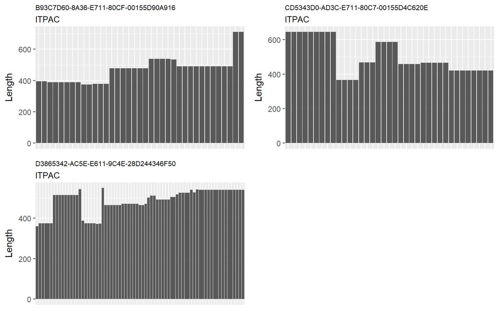

```r
projlength <- function(x) {
    projectLength <-
    x %>%
      group_by(ProjectID, SnapshotDateID) %>%
      summarise(TaskStartDate = min(TaskStartDate), TaskFinishDate = max(TaskFinishDate))

    projectLength$Length <- as.numeric(projectLength$TaskFinishDate - projectLength$TaskStartDate)

    projectLength
    }

##################
#     ITPAC      #
##################

#ITPAC Project Length
projectlength <- projlength(ITPAC)

#Graph all ITPAC projects task counts
cntNumProjects <- nrow((distinct(projectlength, ProjectID)))
ProjectList <- data.frame(distinct(projectlength, ProjectID))

for(i in 1:cntNumProjects){
     df1 <- ungroup(projectlength) %>% filter(ProjectID == ProjectList[i,1])

     assign(paste0("plot", i),ggplot(df1, aes(x=SnapshotDateID, y=Length)) +
          geom_bar(stat="identity") + ggtitle(ProjectList[i,1], subtitle = "ITPAC") + theme(axis.title.x=element_blank(),
          axis.text.x=element_blank(),  axis.ticks.x=element_blank()) + theme(plot.title = element_text(size = 8)))
}

grid.arrange(plot1, plot2, plot3, ncol=2)
```

#### Scalable Form Factor

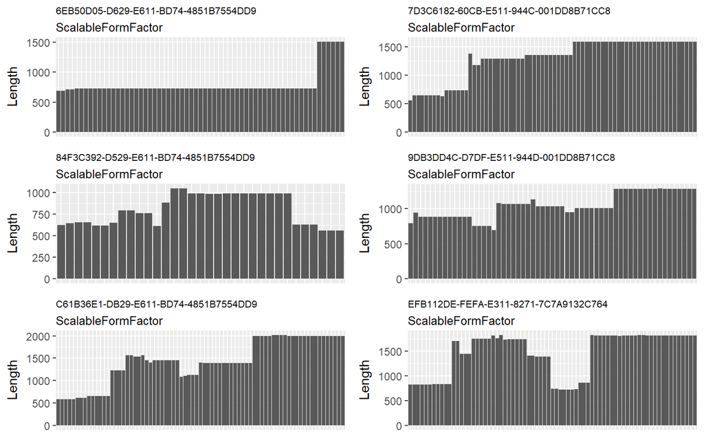

```r
########################
#  ScalableFormFactor  #
########################

#ScalableFormFactor Project Length
projectlength <- projlength(ScalableFormFactor)

#Graph all ScalableFormFactor projects task counts
cntNumProjects <- nrow((distinct(projectlength, ProjectID)))
ProjectList <- data.frame(distinct(projectlength, ProjectID))

for(i in 1:cntNumProjects){
     df1 <- ungroup(projectlength) %>% filter(ProjectID == ProjectList[i,1])

     assign(paste0("plot", i),ggplot(df1, aes(x=SnapshotDateID, y=Length)) +
          geom_bar(stat="identity") + ggtitle(ProjectList[i,1], subtitle = "ScalableFormFactor") + theme(axis.title.x=element_blank(),
          axis.text.x=element_blank(),  axis.ticks.x=element_blank()) + theme(plot.title = element_text(size = 8)))
}

grid.arrange(plot1, plot2, plot3, plot4, plot5, plot6, ncol=2)
```

#### Gen 4.5

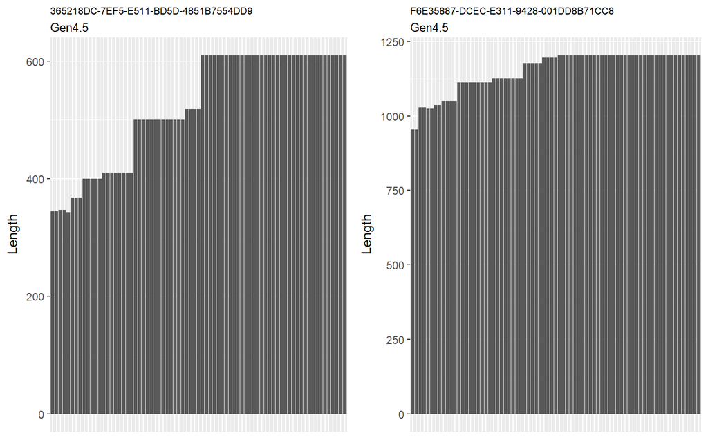

```r
###################
#     Gen4.5      #
###################

#Gen4.5 Project Length
projectlength <- projlength(Gen4.5)

#Graph all Gen4.5 projects task counts
cntNumProjects <- nrow((distinct(projectlength, ProjectID)))
ProjectList <- data.frame(distinct(projectlength, ProjectID))

for(i in 1:cntNumProjects){
     df1 <- ungroup(projectlength) %>% filter(ProjectID == ProjectList[i,1])

     assign(paste0("plot", i),ggplot(df1, aes(x=SnapshotDateID, y=Length)) +
          geom_bar(stat="identity") + ggtitle(ProjectList[i,1], subtitle = "Gen4.5") + theme(axis.title.x=element_blank(),
          axis.text.x=element_blank(),  axis.ticks.x=element_blank()) + theme(plot.title = element_text(size = 8)))
}

grid.arrange(plot1, plot2, ncol=2)
```

#### Gen 4.6

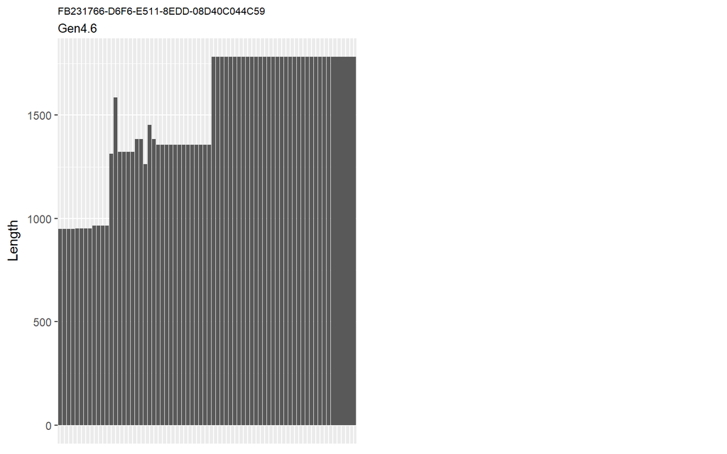

```r
###################
#     Gen4.6      #
###################

#Gen4.6 Project Length
projectlength <- projlength(Gen4.6)

#Graph all Gen4.6 projects task counts
cntNumProjects <- nrow((distinct(projectlength, ProjectID)))
ProjectList <- data.frame(distinct(projectlength, ProjectID))

for(i in 1:cntNumProjects){
     df1 <- ungroup(projectlength) %>% filter(ProjectID == ProjectList[i,1])

     assign(paste0("plot", i),ggplot(df1, aes(x=SnapshotDateID, y=Length)) +
          geom_bar(stat="identity") + ggtitle(ProjectList[i,1], subtitle = "Gen4.6") + theme(axis.title.x=element_blank(),
          axis.text.x=element_blank(),  axis.ticks.x=element_blank()) + theme(plot.title = element_text(size = 8)))
}

grid.arrange(plot1, ncol=2)
```

#### DC 2015

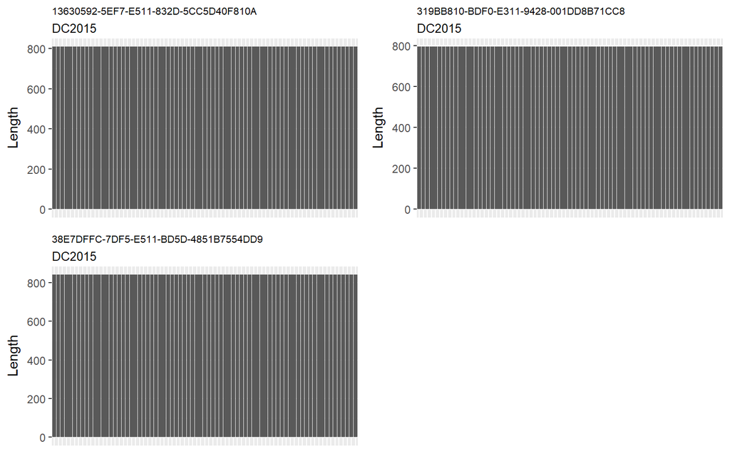

```r
###################
#     DC2015      #
###################

#Gen4.6 Project Length
projectlength <- projlength(DC2015)

#Graph all Gen4.6 projects task counts
cntNumProjects <- nrow((distinct(projectlength, ProjectID)))
ProjectList <- data.frame(distinct(projectlength, ProjectID))

for(i in 1:cntNumProjects){
     df1 <- ungroup(projectlength) %>% filter(ProjectID == ProjectList[i,1])

     assign(paste0("plot", i),ggplot(df1, aes(x=SnapshotDateID, y=Length)) +
          geom_bar(stat="identity") + ggtitle(ProjectList[i,1], subtitle = "DC2015") + theme(axis.title.x=element_blank(),
          axis.text.x=element_blank(),  axis.ticks.x=element_blank()) + theme(plot.title = element_text(size = 8)))
}

grid.arrange(plot1, plot2, plot3, ncol=2)
```

#### DC 2015.5

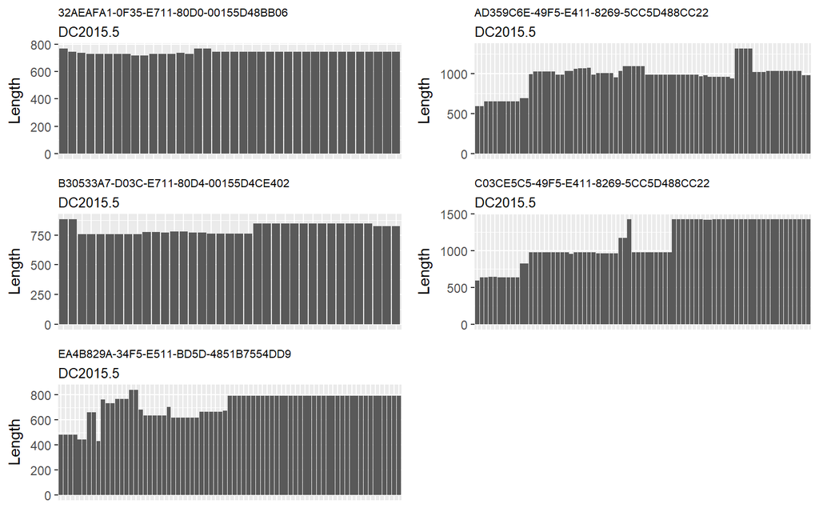

```r
#####################
#     DC2015.5      #
#####################

#Gen4.6 Project Length
projectlength <- projlength(DC2015.5)

#Graph all Gen4.6 projects task counts
cntNumProjects <- nrow((distinct(projectlength, ProjectID)))
ProjectList <- data.frame(distinct(projectlength, ProjectID))

for(i in 1:cntNumProjects){
     df1 <- ungroup(projectlength) %>% filter(ProjectID == ProjectList[i,1])

     assign(paste0("plot", i),ggplot(df1, aes(x=SnapshotDateID, y=Length)) +
          geom_bar(stat="identity") + ggtitle(ProjectList[i,1], subtitle = "DC2015.5") + theme(axis.title.x=element_blank(),
          axis.text.x=element_blank(),  axis.ticks.x=element_blank()) + theme(plot.title = element_text(size = 8)))
}

grid.arrange(plot1, plot2, plot3, plot4, plot5, ncol=2)
```

> The length of the projects per snapshot appear to be variable over time.